# Monitorias de Econometria I (2022)

## Distribuição de Poisson

- Criaremos gráficos com $\lambda = 2.5$
- Os quantis `x` e `q` são números de ocorrências

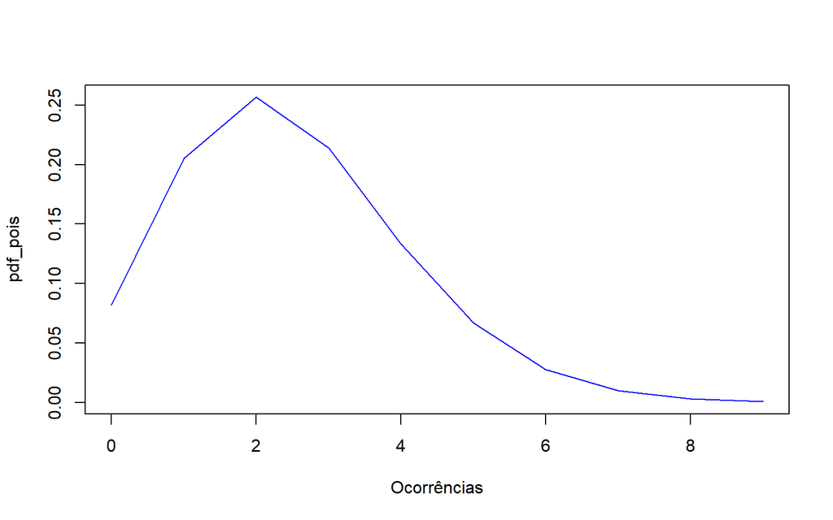

```r
# Gerando sequências de valores de quantis e de probabilidades
quantis = seq(0, 9, by=1)
probs = seq(0.001, 0.999, by=0.001)

# Calculando densidade, distribuição acumulada e quantis
pdf_pois = dpois(quantis, lambda=2.5)
cdf_pois = ppois(quantis, lambda=2.5)
qt_pois = qpois(probs, lambda=2.5)

# Gerando gráficos
plot(quantis, pdf_pois, type="l", col="blue", xlab="Ocorrências") # pdf
```

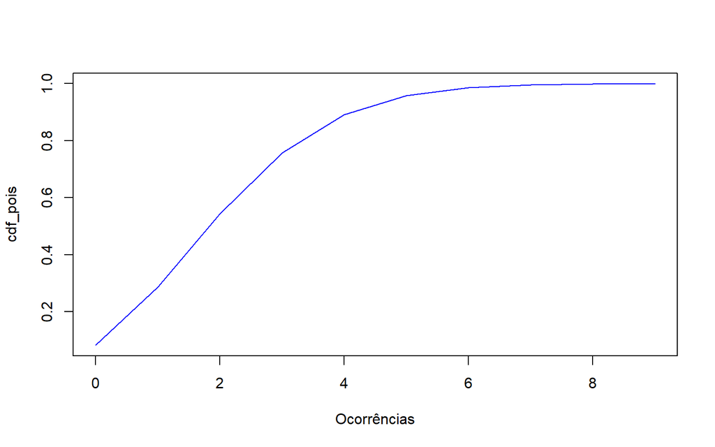

```r
plot(quantis, cdf_pois, type="l", col="blue", xlab="Ocorrências") # cdf
```

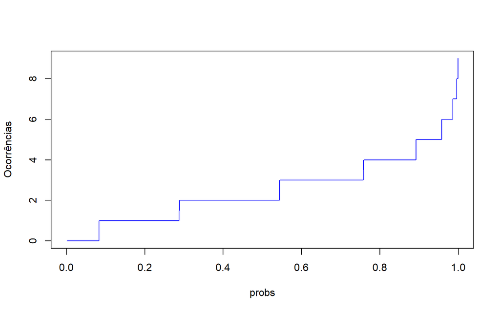

```r
plot(probs, qt_pois, type="l", col="blue", ylab="Ocorrências") # quantis
```

## Distribuição Qui-Quadrado

- Criaremos gráficos com 10 graus de liberdade (`df = 10`)
- Os quantis `x` e `q` são estatísticas de teste cumulativas de Pearson ($\chi^2$)

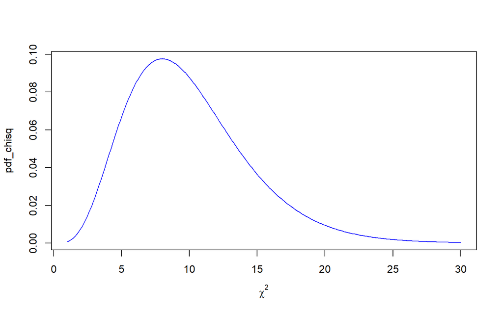

```r
# Gerando sequências de valores de quantis e de probabilidades
quantis = seq(1, 30, by=0.1)
probs = seq(0.001, 0.999, by=0.001)

# Calculando densidade, distribuição acumulada e quantis
pdf_chisq = dchisq(quantis, df=10)
cdf_chisq = pchisq(quantis, df=10)
qt_chisq = qchisq(probs, df=10)

# Gerando gráficos
plot(quantis, pdf_chisq, type="l", col="blue", xlab=expression(chi^2)) # pdf
```

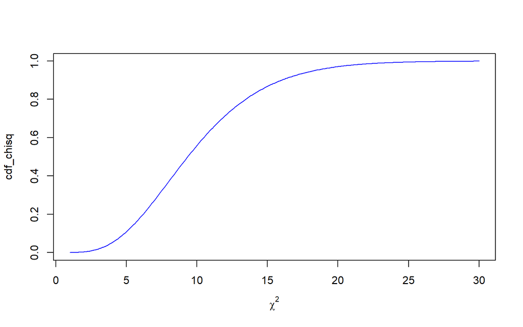

```r
plot(quantis, cdf_chisq, type="l", col="blue", xlab=expression(chi^2)) # cdf
```

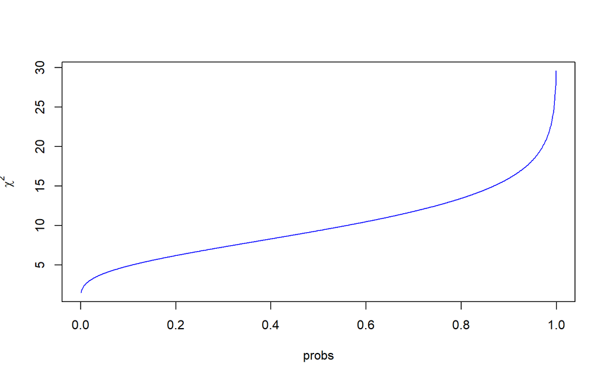

```r
plot(probs, qt_chisq, type="l", col="blue", ylab=expression(chi^2)) # quantis
```

## Distribuição t-Student

- Criaremos gráficos com 10 graus de liberdade (`df = 10`)
- Os quantis `x` e `q` são estatísticas *t*
- Quanto maior os graus de liberdade, mais se aproxima de uma normal (0, 1)

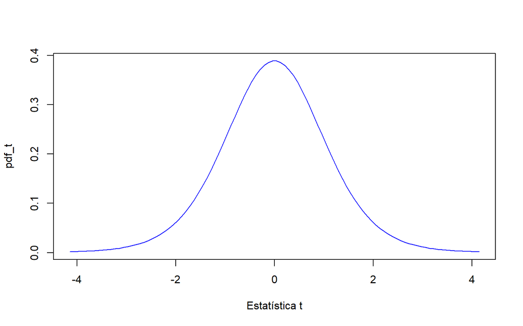

```r
# Gerando sequências de valores de quantis e de probabilidades
quantis = seq(-4.1437, 4.1437, length=100)
probs = seq(0.001, 0.999, by=0.001)

# Calculando densidade, distribuição acumulada e quantis
pdf_t = dt(quantis, df=10)
cdf_t = pt(quantis, df=10)
qt_t = qt(probs, df=10)

# Gerando gráficos
plot(quantis, pdf_t, type="l", col="blue", xlab="Estatística t") # pdf
```

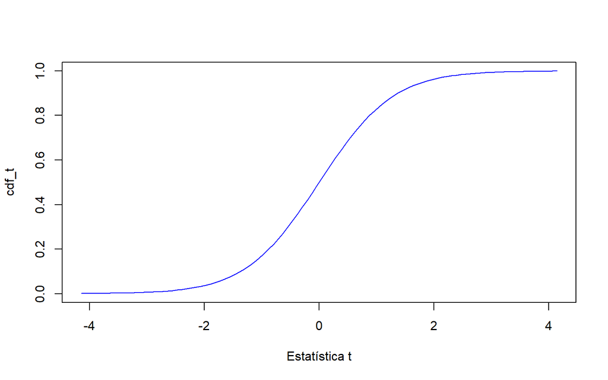

```r
plot(quantis, cdf_t, type="l", col="blue", xlab="Estatística t") # cdf
```

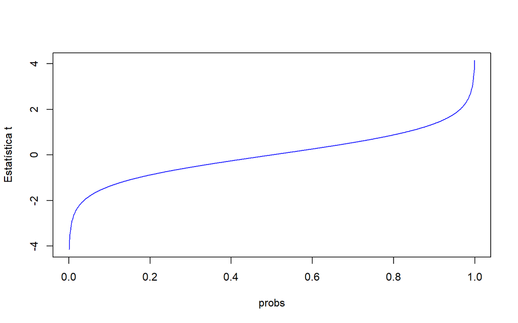

```r
plot(probs, qt_t, type="l", col="blue", ylab="Estatística t") # quantis
```

## Distribuição F

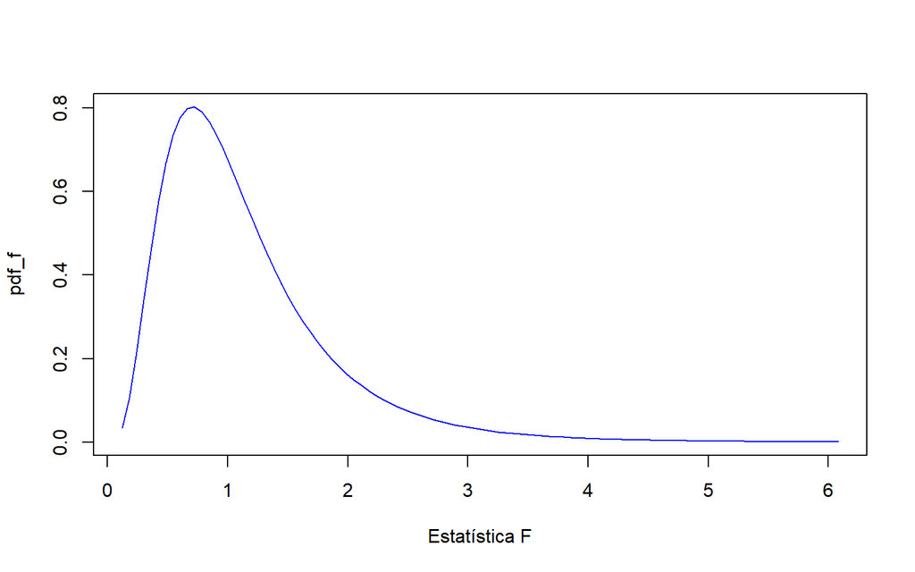

```r
# Gerando sequências de valores de quantis e de probabilidades
quantis = seq(0.1230193, 6.080778, length=100)
probs = seq(0.001, 0.999, by=0.001)

# Calculando densidade, distribuição acumulada e quantis
pdf_f = df(quantis, df1=10, df2=15)
cdf_f = pf(quantis, df1=10, df2=15)
qt_f = qf(probs, df1=10, df2=15)

# Gerando gráficos
plot(quantis, pdf_f, type="l", col="blue", xlab="Estatística F") # pdf
```

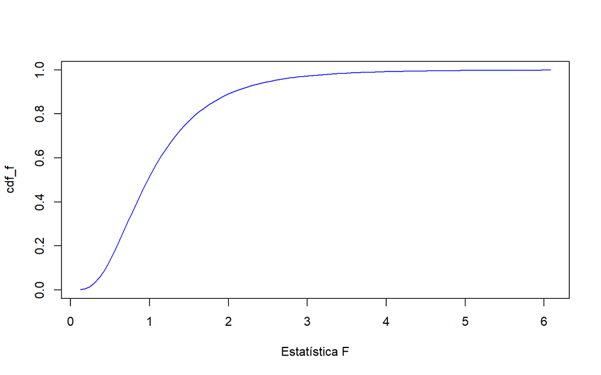

```r
plot(quantis, cdf_f, type="l", col="blue", xlab="Estatística F") # cdf
```

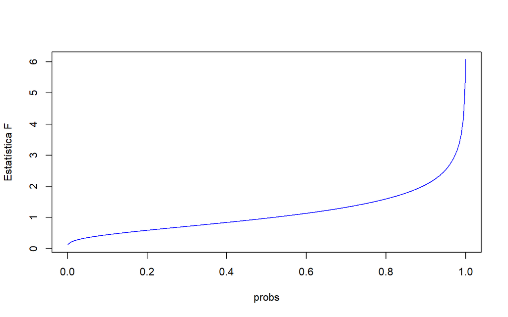

```r
plot(probs, qt_f, type="l", col="blue", ylab="Estatística F") # quantis
```

# Estimação de Modelo Linear

É necessário carregar o pacote `dplyr` para manipulação da base de dados abaixo.

```r
library(dplyr)
```

## Base de dados `mtcars`

Usaremos dados extraídos da *Motor Trend* US magazine de 1974, que analisa o consumo de combustível e 10 aspectos técnicos de 32 automóveis.

No *R*, a base de dados já está incorporada ao programa e pode ser acessada pelo código `mtcars`, contendo a seguinte estrutura:

> - *mpg*: milhas por galão
> - *cyl*: número de cilindros
> - *disp*: deslocamento do motor
> - *hp*: cavalos-vapor bruto
> - *drat*: razão eixo traseiro
> - *wt*: peso (1000 libras)
> - *qsec*: tempo de 1/4 de milha
> - *vs*: motor (0 = forma de V, 1 = reto)
> - *am*: transmissão (0 = automático, 1 = manual)
> - *gear*: número de marchas

Façamos um resumo da base de dados:

```r
### Examinaremos a base da dados mtcars
## Estrutura de mtcars
str(mtcars)
```

```
## 'data.frame':    32 obs. of  11 variables:
##  $ mpg : num  21 21 22.8 21.4 18.7 18.1 14.3 24.4 22.8 19.2 ...
##  $ cyl : num  6 6 4 6 8 6 8 4 4 6 ...
##  $ disp: num  160 160 108 258 360 ...
##  $ hp  : num  110 110 93 110 175 105 245 62 95 123 ...
##  $ drat: num  3.9 3.9 3.85 3.08 3.15 2.76 3.21 3.69 3.92 3.92 ...
##  $ wt  : num  2.62 2.88 2.32 3.21 3.44 ...
##  $ qsec: num  16.5 17 18.6 19.4 17 ...
##  $ vs  : num  0 0 1 1 0 1 0 1 1 1 ...
##  $ am  : num  1 1 1 0 0 0 0 0 0 0 ...
##  $ gear: num  4 4 4 3 3 3 3 4 4 4 ...
##  $ carb: num  4 4 1 1 2 1 4 2 2 4 ...
```

```r
## Selecionando 3 variáveis e resumindo
mtcars %>%
  select(mpg, hp, wt) %>%
  summary()
```

```
##       mpg              hp              wt
##  Min.   :10.40   Min.   : 52.0   Min.   :1.513
##  1st Qu.:15.43   1st Qu.: 96.5   1st Qu.:2.581
##  Median :19.20   Median :123.0   Median :3.325
##  Mean   :20.09   Mean   :146.7   Mean   :3.217
##  3rd Qu.:22.80   3rd Qu.:180.0   3rd Qu.:3.610
##  Max.   :33.90   Max.   :335.0   Max.   :5.424
```

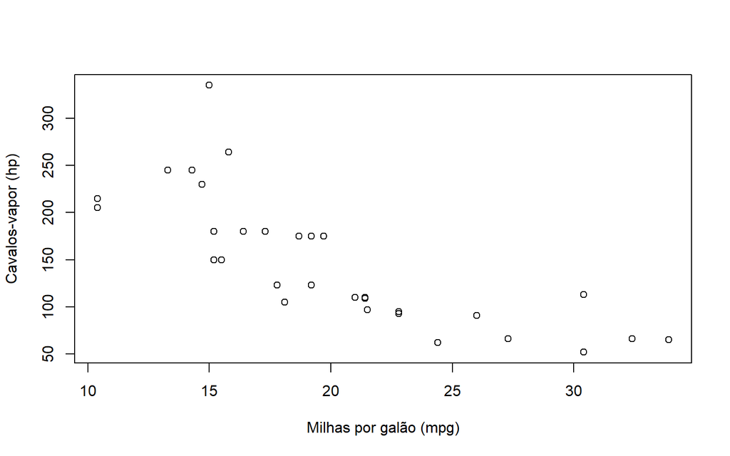

```r
## Plotando consumo de combustível (mpg) por potência do carro (hp)
plot(mtcars$mpg, mtcars$hp, xlab="Milhas por galão (mpg)", ylab="Cavalos-vapor (hp)")
```

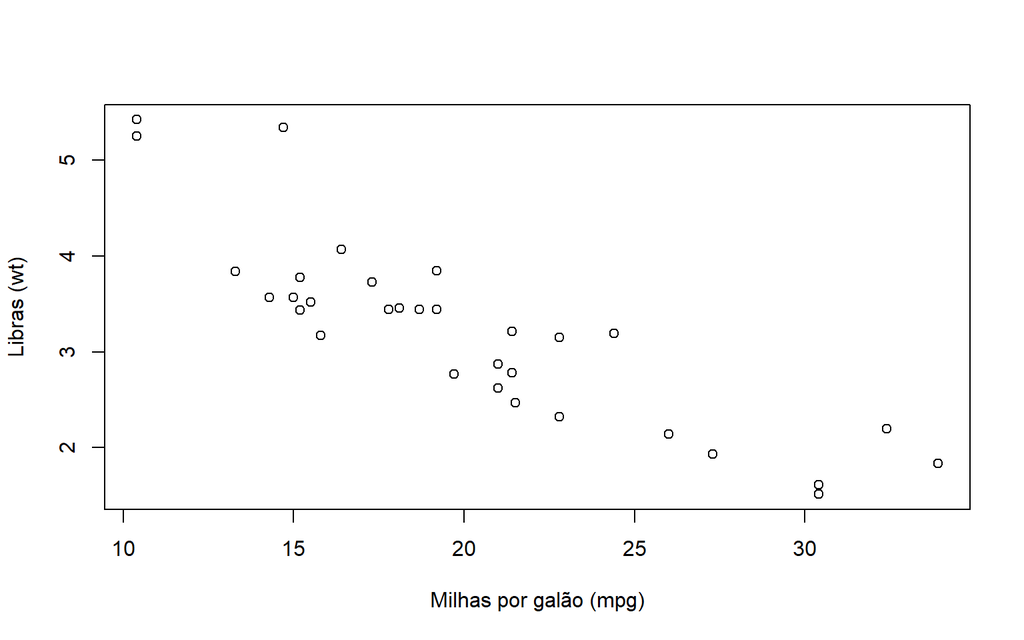

```r
## Plotando consumo de combustível (mpg) por peso do carro (wt)
plot(mtcars$mpg, mtcars$wt, xlab="Milhas por galão (mpg)", ylab="Libras (wt)")
```

Queremos estimar o seguinte modelo:
$$\text{mpg} = \beta_0 + \beta_1 \text{hp} + \beta_2 \text{wt} +
\varepsilon$$

## Estimação por OLS

### Usando a função `lm()`

```
lm(formula, data, subset, weights, na.action,
   method = "qr", model = TRUE, x = FALSE, y = FALSE, qr = TRUE,
   singular.ok = TRUE, contrasts = NULL, offset, ...)

formula: an object of class "formula" (or one that can be coerced to that class): a symbolic description of the model to be fitted.
data: an optional data frame, list or environment (or object coercible by as.data.frame to a data frame) containing the variables in the model.
weights: an optional vector of weights to be used in the fitting process. Should be NULL or a numeric vector.
```

- Em `formula` você irá inserir a variável dependente separada por `~` das variáveis independentes. Estas serão separadas por um `+`. Neste exemplo: `formula = mpg ~ hp + wt`
  - Para incluir uma interação entre variáveis independentes, usa-se `<var1>:<var2>`. Por exemplo: `formula = mpg ~ hp + wt + hp:am`
  - Para fazer uma alteraçao em alguma variável dentro da função `lm()`, usa-se `I()`. Por exemplo, para incluir também o peso do carro, *wt*, ao quadrado: `formula = mpg ~ hp + wt + I(wt^2)`
- Em `data`, será atribuída uma base de dados e, em `weights`, é possível atribuir ponderações para cada observação (bastante comum em bases providas pelo IBGE, como PNAD e POF)

Vamos regredir o consumo de combustível (*mpg*) pela potência (*hp*) e pelo peso (*wt*) do carro:

```r
## Rodar a regressao OLS
fit_ols1 = lm(formula = mpg ~ hp + wt, data = mtcars)

## Resumir os resultados da regressao
summary(fit_ols1)
```

```
##
## Call:
## lm(formula = mpg ~ hp + wt, data = mtcars)
##
## Residuals:
##    Min     1Q Median     3Q    Max
## -3.941 -1.600 -0.182  1.050  5.854
##
## Coefficients:
##             Estimate Std. Error t value Pr(>|t|)
## (Intercept) 37.22727    1.59879  23.285  < 2e-16 ***
## hp          -0.03177    0.00903  -3.519  0.00145 **
## wt          -3.87783    0.63273  -6.129 1.12e-06 ***
## ---
## Signif. codes:  0 '***' 0.001 '**' 0.01 '*' 0.05 '.' 0.1 ' ' 1
##
## Residual standard error: 2.593 on 29 degrees of freedom
## Multiple R-squared:  0.8268, Adjusted R-squared:  0.8148
## F-statistic: 69.21 on 2 and 29 DF,  p-value: 9.109e-12
```

- É possível extrair informações da regressão:

```r
names(fit_ols1) # verificar todas informações contidas no objeto da regressão
```

```
##  [1] "coefficients"  "residuals"     "effects"       "rank"
##  [5] "fitted.values" "assign"        "qr"            "df.residual"
##  [9] "xlevels"       "call"          "terms"         "model"
```

```r
fit_ols1$coefficients # Estimativas
```

```
## (Intercept)          hp          wt
## 37.22727012 -0.03177295 -3.87783074
```

```r
summary(fit_ols1)$coefficients # Estimativas pelo summary()
```

```
##                Estimate Std. Error   t value     Pr(>|t|)
## (Intercept) 37.22727012 1.59878754 23.284689 2.565459e-20
## hp          -0.03177295 0.00902971 -3.518712 1.451229e-03
## wt          -3.87783074 0.63273349 -6.128695 1.119647e-06
```

```r
head(fit_ols1$fitted.values) # valores ajustados
```

```
##         Mazda RX4     Mazda RX4 Wag        Datsun 710    Hornet 4 Drive
##          23.57233          22.58348          25.27582          21.26502
## Hornet Sportabout           Valiant
##          18.32727          20.47382
```

```r
head(fit_ols1$residuals) # resíduos
```

```
##         Mazda RX4     Mazda RX4 Wag        Datsun 710    Hornet 4 Drive
##        -2.5723294        -1.5834826        -2.4758187         0.1349799
## Hornet Sportabout           Valiant
##         0.3727334        -2.3738163
```

#### Variáveis categóricas

- Ao inserir **variáveis categóricas** na regressão, criam-se *dummies* para cada categoria e retira-se uma delas para evitar problema de multicolinearidade:
- No exemplo abaixo, transformaremos a variável de cilindros (*cyl*), que possui apenas 3 valores (4, 6, e 8), na classe *factor*.

```r
mtcars_factor1 = mtcars %>% mutate(cyl = factor(cyl))
summary( lm(mpg ~ cyl, data=mtcars_factor1) )$coef
```

```
##               Estimate Std. Error   t value     Pr(>|t|)
## (Intercept)  26.663636  0.9718008 27.437347 2.688358e-22
## cyl6         -6.920779  1.5583482 -4.441099 1.194696e-04
## cyl8        -11.563636  1.2986235 -8.904534 8.568209e-10
```

- Note que criou apenas 2 *dummies* de cilindros (*cyl6* e *cyl8*), sendo que as suas estimativas são negativas e significativas em relação ao carro com 4 cilindros (*cyl4*) que é a caregoria omitida para evitar multicolinearidade.
- Podemos também definir a categoria a ser omitida usando as funções:
  - `factor(..., levels=c(...))`, quando transforma um vetor em factor (omite o 1º)
  - `relevel(..., ref="")`, quando o vetor já é da classe factor e quer apenas alterar os níveis
- Para omitir *cyl8* fazemos:

```r
# Via relevel() - via factor já existente
mtcars_factor1$cyl = relevel(mtcars_factor1$cyl, ref="8")
summary( lm(mpg ~ cyl, data=mtcars_factor1) )$coef
```

```
##              Estimate Std. Error   t value     Pr(>|t|)
## (Intercept) 15.100000  0.8614094 17.529412 5.660681e-17
## cyl4        11.563636  1.2986235  8.904534 8.568209e-10
## cyl6         4.642857  1.4920048  3.111825 4.152209e-03
```

```r
# Via factor() - omite o 1º nível
mtcars_factor2 = mtcars %>% mutate(cyl = factor(cyl, levels = c(8, 4, 6)))
summary( lm(mpg ~ cyl, data=mtcars_factor2) )$coef
```

```
##              Estimate Std. Error   t value     Pr(>|t|)
## (Intercept) 15.100000  0.8614094 17.529412 5.660681e-17
## cyl4        11.563636  1.2986235  8.904534 8.568209e-10
## cyl6         4.642857  1.4920048  3.111825 4.152209e-03
```

- Observe que as estimativas estão positivas agora, dado que a referência agora é *cyl8*

#### Exportando output em LaTeX

- Podemos usar os pacotes `stargazer` e `textreg` para gerar o output da regressão em LaTeX
- As funções têm os mesmos nomes dos pacotes:

```r
stargazer::stargazer(fit_ols1)
texreg::texreg(fit_ols1)
```

- Depois, copie o output e jogue num programa de LaTeX.

### Estimação Analítica

- [ResEcon 703](https://github.com/woerman/ResEcon703) - Week 2 (University of Massachusetts Amherst)

#### 1. Construir matrizes de covariadas $X$ e da variável dependente $y$

```r
## Criando reg_data a partir de variáveis de mtcars + uma coluna de 1's (p/ constante)
reg_data = mtcars %>%
  select(mpg, hp, wt) %>%  # Selecionando as variáveis dependente e independentes
  mutate(constante = 1)  # Criando coluna de constante

## Selecionando variáveis independentes no objeto X e convertendo em matriz (n x k)
X = reg_data %>%
  select(constante, hp, wt) %>%  # Selecionando as covariadas X (incluindo constante)
  as.matrix()  # Transformando em matrix

## Selecionando a variável dependente no objeto y e convertendo em matriz (n x 1)
y = reg_data %>%
  select(mpg) %>%  # Selecionando as covariadas X (incluindo constante)
  as.matrix()  # Transformando em matrix

## Visualização das primeiras linhas de y e X
head(X)
```

```
##                   constante  hp    wt
## Mazda RX4                 1 110 2.620
## Mazda RX4 Wag             1 110 2.875
## Datsun 710                1  93 2.320
## Hornet 4 Drive            1 110 3.215
## Hornet Sportabout         1 175 3.440
## Valiant                   1 105 3.460
```

```r
head(y)
```

```
##                    mpg
## Mazda RX4         21.0
## Mazda RX4 Wag     21.0
## Datsun 710        22.8
## Hornet 4 Drive    21.4
## Hornet Sportabout 18.7
## Valiant           18.1
```

#### 2. Estimador $\hat{\beta}$

O estimador de OLS é dado por:
$$\hat{\beta} = (X'X)^{-1} X' y$$

```r
## Estimando os parametros beta
beta_hat = solve(t(X) %*% X) %*% t(X) %*% y # solve() calcula a inversa
beta_hat
```

```
##                   mpg
## constante 37.22727012
## hp        -0.03177295
## wt        -3.87783074
```

#### 3. Calcular os valores ajustados $\hat{y}$

$$\hat{y} = X\hat{\beta}$$

```r
## Calculando os valores ajustados de y
y_hat = X %*% beta_hat
colnames(y_hat) = "mpg_hat"
head(y_hat)
```

```
##                    mpg_hat
## Mazda RX4         23.57233
## Mazda RX4 Wag     22.58348
## Datsun 710        25.27582
## Hornet 4 Drive    21.26502
## Hornet Sportabout 18.32727
## Valiant           20.47382
```

#### 4. Calcular os resíduos $e$

$$\varepsilon = y - \hat{y}$$

```r
## Calculando os residuos
e = y - y_hat
colnames(e) = "e"
head(e)
```

```
##                            e
## Mazda RX4         -2.5723294
## Mazda RX4 Wag     -1.5834826
## Datsun 710        -2.4758187
## Hornet 4 Drive     0.1349799
## Hornet Sportabout  0.3727334
## Valiant           -2.3738163
```

#### 5. Calcular a variância do termo de erro $s^2$

$$\hat{\sigma}^2 = \frac{e'e}{n-k}$$

```r
## Estimando variancia do termo de erro
sigma2 = t(e) %*% e / (nrow(X) - ncol(X))
sigma2
```

```
##          e
## e 6.725785
```

#### 6. Calcular a matriz de covariâncias $\hat{Cov}(\widehat{\beta})$

$$\widehat{Cov}(\hat{\beta}) =
\hat{\sigma}^2 (X'X)^{-1}$$

```r
## Estimando a matriz de variancia/covariancia das estimativas beta
vcov_hat = c(sigma2) * solve(t(X) %*% X)
vcov_hat
```

```
##               constante            hp          wt
## constante  2.5561215917  1.484701e-04 -0.73594515
## hp         0.0001484701  8.153566e-05 -0.00376369
## wt        -0.7359451464 -3.763690e-03  0.40035167
```

#### 7. Calcular erros padrão, estatísticas t, e p-valores

```r
## Calculando erros padrao das estimativas beta
std_err = sqrt(diag(vcov_hat)) # Raiz da diagonal da matriz de covariâncias

## Calculando estatisticas t das estimativas beta
t_stat = beta_hat / std_err

## Calculando p-valores das estimativas beta
p_value = 2 * pt(q = -abs(t_stat), df = nrow(X) - ncol(X)) # 2 x acumulada até estatística t negativa

## Organizando os resultados da regressao em uma matriz
results = cbind(beta_hat, std_err, t_stat, p_value)

## Nomeando as colunas da matriz de resultados
colnames(results) = c('Estimate', 'Std. Error', 't stat', 'Pr(>|t|)')
results
```

```
##              Estimate Std. Error    t stat     Pr(>|t|)
## constante 37.22727012 1.59878754 23.284689 2.565459e-20
## hp        -0.03177295 0.00902971 -3.518712 1.451229e-03
## wt        -3.87783074 0.63273349 -6.128695 1.119647e-06
```

### Estimação Numérica

#### 1. Criar função perda que calcula a soma dos desvios quadráticos

- A função para calcular a soma dos desvios quadráticos recebe como inputs:
  - um **vetor** de possíveis valores para $\beta_0$, $\beta_1$ e $\beta_2$
  - uma base de dados

```r
desv_quad = function(params, data) {
  # Extraindo os parâmetros para objetos
  beta_0 = params[1]
  beta_1 = params[2]
  beta_2 = params[3]

  mpg_ajustado = beta_0 + beta_1*data$hp + beta_2*data$wt # valores ajustados
  desvios = data$mpg - mpg_ajustado # desvios = observados - ajustados
  sum(desvios^2)
}
```

#### 2. Otimização

- Agora encontraremos os parâmetros que minimizam a função perda
  $$\text{argmin}_{\theta \in \Theta}
  \sum_{i=1}^{N}\left( \text{mpg}_i - \widehat{\text{mpg}}_i \right)^2$$
- Para isto usaremos a função `optim()` que retorna os parâmetros que minimizam uma função (equivalente ao *argmin*):

```yaml
optim(par, fn, gr = NULL, ...,
      method = c("Nelder-Mead", "BFGS", "CG", "L-BFGS-B", "SANN", "Brent"),
      lower = -Inf, upper = Inf,
      control = list(), hessian = FALSE)

par: Initial values for the parameters to be optimized over.
fn: A function to be minimized (or maximized), with first argument the vector of parameters over which minimization is to take place. It should return a scalar result.
method: The method to be used. See ‘Details’. Can be abbreviated.
hessian: Logical. Should a numerically differentiated Hessian matrix be returned?
```

- Colocaremos como input:
  - a função perda criada `desv_quad()`
  - um chute inicial dos parâmetros
    - Note que a estimação pode ser mais ou menos sensível ao valores iniciais, dependendo do método de otimização utilizado
    - O mais comum é encontrar como chute inicial um vetor de zeros `c(0, 0, 0)`, por ser mais neutro em relação ao sinal das estimativas
    - Em Econometria III, prof. Laurini recomendou usar método “Nelder-Mead” (padrão) com um chute inicial de zeros e, depois, usar suas estimativas como chute inicial para o método “BFGS”.
  - Por padrão, temos o argumento `hessian = FALSE`, coloque `TRUE` para calcularmos o erro padrão, estatística t e p-valor das estimativas

```r
# Estimação por BFGS
theta_ini = c(0, 0, 0) # Chute inicial de beta_0, beta_1 e beta_2

fit_ols2 = optim(par=theta_ini, fn=desv_quad, data=mtcars,
                  method="BFGS", hessian=TRUE)
fit_ols2
```

```
## $par
## [1] 37.22727012 -0.03177295 -3.87783074
##
## $value
## [1] 195.0478
##
## $counts
## function gradient
##       34        6
##
## $convergence
## [1] 0
##
## $message
## NULL
##
## $hessian
##          [,1]       [,2]       [,3]
## [1,]   64.000    9388.00   205.9040
## [2,] 9388.000 1668556.00 32943.4880
## [3,]  205.904   32943.49   721.8021
```

## Métodos de Otimização Básicos

- Essa seção tem o objetivo para dar uma intuição sobre métodos de otimização e está baseada em Hamilton (1994), seção 5.7.
- Veremos os métodos de *grid search* (discretização) e *steepest ascent* que são métodos simples, mas que representam famílias de métodos de otimização.
- Para maior profundidade no assunto, sugiro cursar disciplina de Economia Computacional.

### *Grid Search*

- O método mais simples de otimização numérica é o *grid search* (discretização).
- Como o R não lida com problemas com infinitos valores, uma forma lidar com isso é discretizando diversos possíveis valores dos parâmetros de escolha dentro de intervalos.
- Para cada possível combinação de parâmetros, calculam-se diversos valores a partir da função objetivo. De todos os valores calculados, escolhe-se a combinação de parâmetros que maximizam (ou minimizam) a função objetivo.
- O exemplo abaixo considera apenas um parâmetro de escolha $\theta$ e, para cada ponto escolhido dentro do intervalo $[-1, 1]$, calcula-se a função objetivo:

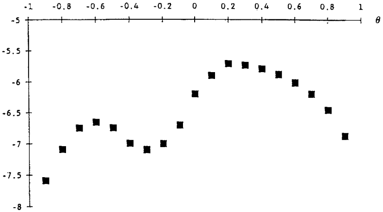

- Este é um método robusto a funções com descontinuidades e quinas (não diferenciáveis), e menos sensível a chutes de valores iniciais. (ver método abaixo)
- Porém, por ter que fazer cálculo da função objetivo para inúmeros pontos, tende a ser menos eficiente.

### *Steepest Ascent*

- Conforme o número de parâmetros do modelo cresce, aumenta o número de possíveis combinações entre parâmetros e torna o processo computacional cada vez mais lento.
- Uma forma mais eficiente de encontrar o conjunto de parâmetros que otimizam a função objetivo é por meio do método *steepest ascent*.
- Seja $\theta^*$ o conjunto de parâmetros que maximiza a função objetivo:
  1. Comece com alguns valores iniciais dos parâmetros, $\theta^0$
  2. Calcula-se o gradiente e avalia-se a possibilidade de “andar para cima” a um valor mais alto
  3. Caso possa, ande na direção correta a $\theta_1$
  4. Repita os passos (2) e (3), andando de $\theta^s$ para $\theta^{s+1}$ até atingir o máximo com $\theta^*$.

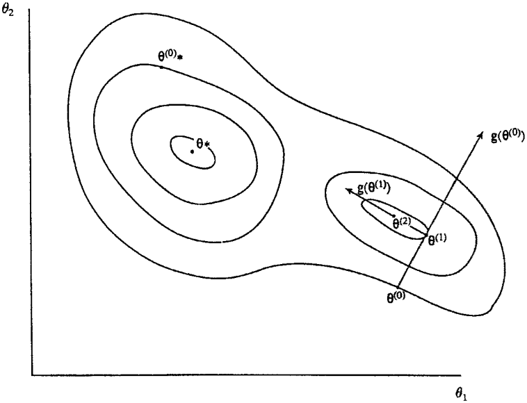

- Note que esse método de otimização é sensível ao conjunto de parâmetros iniciais e a descontinuidades da função objetivo.
- Por outro lado, é um método mais eficiente (calcula uma função objetivo dado os parâmetros a cada passo que dá) e tende a ser também mais preciso nas estimações.

## Estimação por MLE

- [ResEcon 703](https://github.com/woerman/ResEcon703) - Week 6 (University of Massachusetts Amherst)

### Intuição do cálculo da função de verossimilhança

- Apenas para ilustrar a construção da função de verossimilhança, considere um modelo logit em que queremos estimar os indivíduos precisam escolher se usam carro ou ônibus para deslocamento.
- Para estimar as probabilidades de usar carro (e, por consequência, de ônibus), vamos utilizar as informações dos preços que os indivíduos pagam pela gasolina e pela passagem de ônibus.
- Note que os valores abaixo foram todos inventados.
- Considere um conjunto de parâmetros $\theta^A = \{ \beta^A_0, \beta^A_1, \beta^A_2 \}$ que gerem as seguintes probabilidades de usar carro e de ônibus (últimas 2 colunas):

|  | **Preço Gasolina** | **Preço Bus** | **Escolha** | *Prob(Car $\| \theta^A$)* | *Prob(Bus $\| \theta^A$)* |
| --- | --- | --- | --- | --- | --- |
| Indiv. 1 | 6,93 | 5,00 | Car | **0,63** | 0,37 |
| Indiv. 2 | 7,01 | 2,50 | Bus | 0,33 | **0,67** |
| Indiv. 3 | 6,80 | 2,50 | Bus | 0,25 | **0,75** |
| Indiv. 4 | 6,75 | 5,00 | Car | **0,73** | 0,27 |

- Logo, a verossimilhança, dado os parâmetros $\theta^A$ é
  $$\mathcal{L}(\theta^A) = 0,63 \times 0,67 \times 0,75 \times 0,73 = 0,231$$
- Agora, considere $\theta^B = \{ \beta^B_0, \beta^B_1, \beta^B_2 \}$ que gerem as seguintes probabilidades:

|  | **Preço Gasolina** | **Preço Bus** | **Escolha** | *Prob(Car $\| \theta^B$)* | *Prob(Bus $\| \theta^B$)* |
| --- | --- | --- | --- | --- | --- |
| Indiv. 1 | 6,93 | 5,00 | Car | **0,54** | 0,46 |
| Indiv. 2 | 7,01 | 2,50 | Bus | 0,43 | **0,57** |
| Indiv. 3 | 6,80 | 2,50 | Bus | 0,35 | **0,65** |
| Indiv. 4 | 6,75 | 5,00 | Car | **0,58** | 0,42 |

- Então, a verossimilhança, dado $\theta^B$, é
  $$\mathcal{L}(\theta^B) = 0,54 \times 0,57 \times 0,65 \times 0,58 = 0,116$$
- Como $\mathcal{L}(\theta^A) = 0,231 > 0,116 = \mathcal{L}(\theta^B)$, então os parâmetros $\theta^A$ se mostram mais adequados em relação a $\theta^B$
- Na máxima verossimilhança (MLE), é escolhido o conjunto de parâmetros $\theta^*$ que maximiza a função de verossimilhança (ou log-verossimilhança).
- No modelo logit, as probabilidades usadas para calcular a verossimilhança são as próprias proabilidades de escolha por uma alternativa, dado um conjunto de parâmetros.
- Já no modelo linear, usamos a função de densidade de probabilidade para avaliar a “distância” de cada observação, $y_i$, em relação ao seu valor ajustado $\hat y_i$, dado um conjunto de parâmetros.

### Otimização Numérica para MLE

A função `optim()` do R será usada novamente para desempenhar a otimização numérica. Precisamos usar como input:

- Alguns valores inicias dos parâmetros, $\theta^0$
- Uma função que tome esses parâmetros como um argumento e calcule a log-verossimilhança, $\ln{L(\theta)}$.

A função log-verossimilhança é dada por
$$\ln{L(\beta, \sigma^2 | y, X)} = \sum^n_{i=1}{\ln{f(y_i | x_i, \beta,
\sigma^2)}},$$
em que a distribuição condicional de cada $y_i$ é
$$y_i |
x_i \sim \mathcal{N}(\beta'x_i, \sigma^2)$$

1. Construir matriz $X$ e vetor $y$
2. Calcular os valores ajustados de $y$, $\hat{y} - \beta'x_i$, que é a média de cada $y_i$
3. Calcular a densidade para cada $y_i$, $f(y_i | x_i, \beta, \sigma^2)$
4. Calcular a log-verossimilhança, $\ln{L(\beta, \sigma^2 | y, X)} = \sum^n_{i=1}{\ln{f(y_i | x_i, \beta, \sigma^2)}}$

#### 1. Chute de valores iniciais para $\beta_0, \beta_1, \beta_2$ e $\sigma^2$

- Note que, diferente da estimação por OLS, um dos parâmetros a ser estimado via MLE é a variância ($\sigma^2$).

```r
params = c(35, -0.02, -3.5, 1)
# (beta_0, beta_1 , beta_2, sigma2)
```

#### 2. Seleção da base de dados e variáveis

```r
## Adicionando colunas de 1's para o termo constante
data = mtcars
beta_0 = params[1]
beta_1 = params[2]
beta_2 = params[3]
sigma2 = params[4]
```

#### 3. Cálculo dos valores ajustados e das densidades

```r
## Calculando valores ajustados de y
y_hat = beta_0 + beta_1*data$hp + beta_2*data$wt
```

#### 4. Cálculo das densidades

$$f(y_i | x_i, \beta, \sigma^2)$$

```r
## Calculando os pdf's de cada outcome
y_pdf = dnorm(data$mpg, mean = y_hat, sd = sqrt(sigma2))

head(y_pdf) # Primeiros valores da densidade
```

```
## [1] 0.01255811 0.08817854 0.03394076 0.39462606 0.29887241 0.01070560
```

```r
prod(y_pdf) # Verossimilhança
```

```
## [1] 2.331786e-67
```

- Agora, vamos juntar o data frame `mtcars` com os valores ajustados `mpg_hat` e as densidades `y_pdf`:

```r
mpg_hat = y_hat # atribuindo y_hat a um objeto com nome mais adequado

# Juntando as bases e visualizando os primeiros valores
bd_joined = cbind(mtcars, mpg_hat, y_pdf) %>%
  select(hp, wt, mpg, mpg_hat, y_pdf)
head(bd_joined)
```

```
##                    hp    wt  mpg mpg_hat      y_pdf
## Mazda RX4         110 2.620 21.0 23.6300 0.01255811
## Mazda RX4 Wag     110 2.875 21.0 22.7375 0.08817854
## Datsun 710         93 2.320 22.8 25.0200 0.03394076
## Hornet 4 Drive    110 3.215 21.4 21.5475 0.39462606
## Hornet Sportabout 175 3.440 18.7 19.4600 0.29887241
## Valiant           105 3.460 18.1 20.7900 0.01070560
```

- Como pode ser visto na base de dados juntada e nos gráficos abaixo, quanto mais próximo o valor ajustado for do valor observado de cada observação, maior será a densidade/probabilidade.

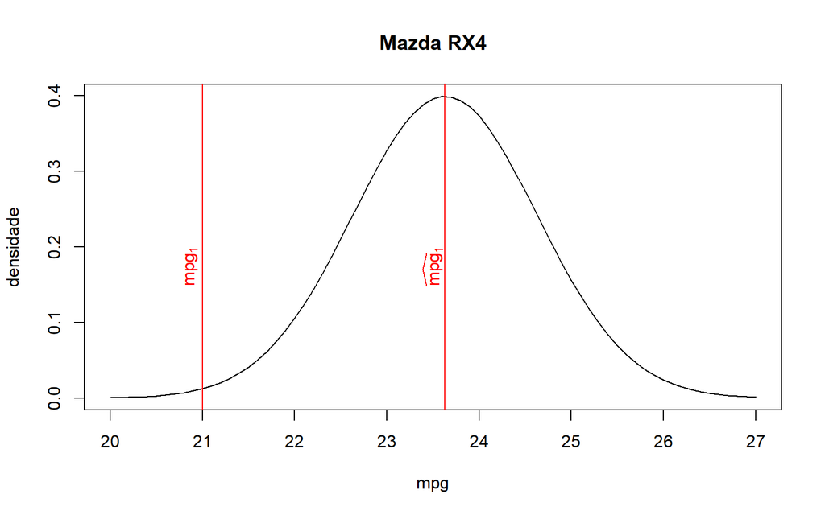

```r
# Criando gráfico para os 2 primeiros carros (Mazda RX4 e Mazda RX 4 Wag)
qt_norm = seq(20, 27, by=0.1) # valores de mpg ("escores Z")

# Mazda RX4
pdf_norm1 = dnorm(qt_norm, mean=bd_joined$mpg_hat[1], sd=sqrt(sigma2)) # pdf
plot(qt_norm, pdf_norm1, type="l", xlab="mpg", ylab="densidade", main="Mazda RX4")
abline(v=c(bd_joined$mpg_hat[1], bd_joined$mpg[1]), col="red")
text(c(bd_joined$mpg_hat[1], bd_joined$mpg[1]), 0.2,
     c(expression(widehat(mpg)[1]), expression(mpg[1])),
     pos=2, srt=90, col="red")
```

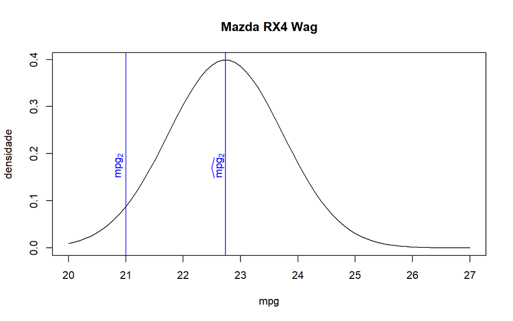

```r
# Mazda RX4 Wag
pdf_norm2 = dnorm(qt_norm, mean=bd_joined$mpg_hat[2], sd=sqrt(sigma2)) # pdf
plot(qt_norm, pdf_norm2, type="l", xlab="mpg", ylab="densidade", main="Mazda RX4 Wag")
abline(v=c(bd_joined$mpg_hat[2], bd_joined$mpg[2]), col="blue")
text(c(bd_joined$mpg_hat[2], bd_joined$mpg[2]), 0.2,
     c(expression(widehat(mpg)[2]), expression(mpg[2])),
     pos=2, srt=90, col="blue")
```

- Logo, a verossimilhança (produto de todas probabilidades) será maior quanto mais próximos forem os valores ajustados dos seus respectivos valores observados.

#### 5. Calculando a Log-Verossimilhança

$$\mathcal{l}(\beta, \sigma^2) =
\sum^{N}_{i=1}{\ln\left[ f(y_i | x_i, \beta, \sigma^2) \right]}$$

```r
## Calculando a log-verossimilhanca
loglik = sum(log(y_pdf))
loglik
```

```
## [1] -153.4266
```

#### 6. Criando a Função de Log-Verossimilhança

```r
## Criando funcao para calcular log-verossimilhanca OLS
loglik_lm = function(params, data) {
  # Pegando os parâmetros
  beta_0 = params[1]
  beta_1 = params[2]
  beta_2 = params[3]
  sigma2 = params[4]

  ## Calculando valores ajustados de y
  y_hat = beta_0 + beta_1*data$hp + beta_2*data$wt

  ## Calculando os pdf's de cada outcome
  y_pdf = dnorm(data$mpg, mean = y_hat, sd = sqrt(sigma2))

  ## Calculando a log-verossimilhanca
  loglik = sum(log(y_pdf))

  ## Retornando o negativo da log-verossimilanca - optim() não maximiza
  -loglik
}
```

#### 7. Otimização

Tendo a função objetivo, usaremos `optim()` para *minimizar*
$$-\ln{L(\beta, \sigma^2
| y, X)} = -\sum^n_{i=1}{\ln{f(y_i | x_i, \beta, \sigma^2)}}.$$
Aqui, **minimizamos o negativo** da log-Verossimilhança para **maximizarmos** (função`optim()` apenas minimiza).

```r
## Maximizando a função log-verossimilhança OLS
mle = optim(par = c(0, 0, 0, 1), fn = loglik_lm, data = mtcars,
              method = "BFGS", hessian = TRUE)

## Mostrando os resultados da otimização
mle
```

```
## $par
## [1] 37.227256 -0.031773 -3.877825  6.095146
##
## $value
## [1] 74.32617
##
## $counts
## function gradient
##      105       41
##
## $convergence
## [1] 0
##
## $message
## NULL
##
## $hessian
##              [,1]         [,2]         [,3]         [,4]
## [1,] 5.250080e+00 7.701211e+02 1.689082e+01 1.715961e-06
## [2,] 7.701211e+02 1.368758e+05 2.702437e+03 2.252101e-04
## [3,] 1.689082e+01 2.702437e+03 5.921123e+01 2.589928e-06
## [4,] 1.715961e-06 2.252101e-04 2.589928e-06 4.306909e-01
```

```r
## Calculando os erros padrão
mle_se = mle$hessian %>% # hessiano
  solve() %>% # toma a inversa para obter a matriz de var/cov
  diag() %>% # pega a diagonal da matriz
  sqrt() # calcula a raiz quadrada

# Visualizando as estimativas e os erros padrão
cbind(mle$par, mle_se)
```

```
##                     mle_se
## [1,] 37.227256 1.521988303
## [2,] -0.031773 0.008595959
## [3,] -3.877825 0.602339558
## [4,]  6.095146 1.523762060
```

## Estimação por GMM

- [Computing Generalized Method of Moments and Generalized Empirical Likelihood with R (Pierre Chaussé)](https://cran.r-project.org/web/packages/gmm/vignettes/gmm_with_R.pdf)
- [Generalized Method of Moments (GMM) in R - Part 1 (Alfred F. SAM)](https://medium.com/codex/generalized-method-of-moments-gmm-in-r-part-1-of-3-c65f41b6199)
- Para estimar via GMM precisamos construir vetores relacionados aos seguintes momentos:
  $$E(\varepsilon) = 0
  \qquad \text{ e } \qquad E(\varepsilon'X) = 0$$
  em que $X$ é a matriz de covariadas e $\varepsilon$ é o desvio. Note que estes são os momentos relacionados ao OLS, dado que este é um caso particular do GMM.
- Relembre que estamos usando a base de dados `mtcars` para estimar o modelo linear:
  $$\text{mpg} =
  \beta_0 + \beta_1 \text{hp} + \beta_2 \text{wt} + \varepsilon$$
  que relaciona o consumo de combustível (em milhas por galão - *mpg*) com a potência (*hp*) e o peso (em mil libras - *wt*) do carro.

### Otimização Numérica para GMM

#### 1. Chute de valores iniciais para $\beta_0$, $\beta_1$ e $\beta_2$

- Vamos criar um vetor com possíveis valores de $\beta_0, \beta_1, \beta_2$:

```r
library(dplyr)

params = c(35, -0.02, -3.5)
beta_0 = params[1]
beta_1 = params[2]
beta_2 = params[3]
```

#### 2. Seleção da base de dados e variáveis

```r
data = mtcars %>% mutate(constant=1) # Criando variável de constante

## Selecionando colunas para X (covariadas) e convertendo para matrix
X = data %>%
  select("constant", "hp", "wt") %>%
  as.matrix()

## Selecionando variavel para y e convertendo para matrix
y = data %>%
  select("mpg") %>%
  as.matrix()
```

#### 3. Cálculo dos valores ajustados e dos desvios

```r
## Valores ajustados e desvios
y_hat = X %*% params
# equivalente a: y_hat = beta_0 + beta_1 * X[,"hp"] + beta_2 * X[,"wt"]

e = y - y_hat
```

#### 4. Criação da matriz de momentos

- Note que $E(\varepsilon' X)$ é uma multiplicação matricial, mas a função `gmm()` exige que como input os vetores com multiplicação elemento a elemento do resíduo $\varepsilon$ com as covariadas $X$ (neste caso: constante, hp, wt)

```r
m = X * as.vector(e) # matriz de momentos (sem tomar esperança)
head(m)
```

```
##                   constant       hp         wt
## Mazda RX4          -2.6300 -289.300 -6.8906000
## Mazda RX4 Wag      -1.7375 -191.125 -4.9953125
## Datsun 710         -2.2200 -206.460 -5.1504000
## Hornet 4 Drive     -0.1475  -16.225 -0.4742125
## Hornet Sportabout  -0.7600 -133.000 -2.6144000
## Valiant            -2.6900 -282.450 -9.3074000
```

- Note que, como multiplicamos a constante igual a 1 com os desvios $\varepsilon$, a 1ª coluna corresponde ao momento $E(\varepsilon)=0$ (mas sem tomar a esperança).
- Já as colunas 2 e 3 correspodem ao momento $E(\varepsilon'X)=0$ para as variáveis *hp* e *wt* (também sem tomar a esperança).
- Logicamente, para estimar por GMM, precisamos escolher os parâmetros $\theta = \{ \beta_0, \beta_1, \beta_2 \}$ que, ao tomar a esperança em cada um destas colunas, se aproximem ao máximo de zero. Isso será feito via função `gmm()` (semelhante à função `optim()`)

#### 5. Criação de função com os momentos

- Vamos criar uma função que tem como input um vetor de parâmetros (`params`) e uma base de dados (`data`), e que retorna uma matriz em que cada coluna representa um momento.
- Essa função incluirá todos os comandos descritos nos itens 1 a 4 (que, na verdade, apenas foram feitos por didática).

```r
mom_ols = function(params, data) {
  ## Adicionando colunas de 1's para o termo constante
  data = data %>% mutate(constant = 1)

  ## Selecionando colunas para X (covariadas) e convertendo para matrix
  X = data %>%
    select("constant", "hp", "wt") %>%
    as.matrix()

  ## Selecionando variavel para y e convertendo para matrix
  y = data %>%
    select("mpg") %>%
    as.matrix()

  ## Valores ajustados e desvios
  y_hat = X %*% params
  e = y - y_hat

  m = as.vector(e) * X # matriz de momentos (vetor - multiplicação por elemento)
  m
}
```

#### 6. Otimização via função `gmm()`

- A função `gmm()`, assim como a `optim()`, recebe uma função como argumento.
- No entanto, ao invés de retornar um valor, a função que entra no `gmm()` retorna uma matriz, cujas médias das colunas queremos aproximar de zero.

```r
library(gmm)
gmm_lm = gmm(mom_ols, mtcars, c(0,0,0),
             wmatrix = "optimal", # matriz de ponderação
             optfct = "nlminb" # função de otimização
             )

summary(gmm_lm)$coefficients
```

```
##             Estimate  Std. Error   t value      Pr(>|t|)
## Theta[1] 37.22727054 1.477465796 25.196705 4.352959e-140
## Theta[2] -0.03177295 0.007330972 -4.334070  1.463775e-05
## Theta[3] -3.87783083 0.595735804 -6.509313  7.549526e-11
```

# Dados em Painel

## Manipulação de dados em painel

- Para o que estamos estudando, é normalmente exigido que os dados estejam
  - no formato *long*: para cada indivíduo, temos uma linha para cada período;
  - *balanceados*: o tamanho da amostra é $N \times T$, com $N$ indivíduos e $T$ períodos; e
  - devidamente ordenados por indivíduos e, depois, por tempo.

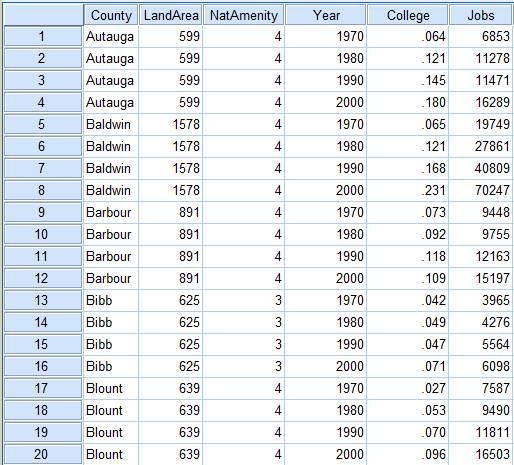

- Em muitos casos, as informações são disponibilizadas em várias bases de dados de cortes transversais (*cross sections*), então é necessário estruturar a base de dados em painel.
- Isso por ser feito no R de, pelo menos, duas formas:
  - empilhando as bases de dados e filtrando apenas indivíduos que aparecem em todos períodos; ou
  - fazendo a junção interna (*inner join*) das bases por indivíduo e transformando do formato *wide* para o *long*.
- Como exemplo, usaremos a PNAD Contínua que é publicada trimestralmente e possui o pacote `PNADcIBGE` que auxilia na sua utilização.
- Os dados podem ser obtidos via:
  - `read_pnadc(microdata, input_txt)`: que necessita que você faça download das bases de dados e do txt com informações das variáveis (*input_txt*) no [FTP do IBGE](https://ftp.ibge.gov.br/Trabalho_e_Rendimento/Pesquisa_Nacional_por_Amostra_de_Domicilios_continua/Trimestral/Microdados/); ou
  - `get_pnadc(year, quarter = NULL, design = TRUE)`: que faz o download diretamente do R e atribui para um objeto. É necessário informar a data da pesquisa (ano e trimestre) e, para retornar um data frame, altere o argumento para `design = FALSE` (caso contrário, irá retornar um objeto do tipo `survey.design`)

```r
# install.packages("PNADcIBGE")
library(PNADcIBGE)
library(dplyr)

# Carregando as bases da PNADc via get_pnadc()
# pnad_012021 = get_pnadc(year=2021, quarter=1, design=FALSE)
# pnad_022021 = get_pnadc(year=2021, quarter=2, design=FALSE)

# Carregando as bases da PNADc em .txt presentes no computador
pnad_012021 = read_pnadc("PNADc/PNADC_012021.txt", input_txt = "PNADc/input_PNADC_trimestral.txt")
```

- Note que o arquivo compactado .zip é cerca de 12% do arquivo descompactado .txt (133mb $\times$ 1,08gb). Para não precisar manter o arquivo .txt no computador, podemos usar a função `unz()` para descompactar arquivos temporariamente:

```r
# Descompactando as bases da PNADc e carregando no R
# pnad_012021 = read_pnadc(unz("PNADc/PNADC_012021_20220224.zip", "PNADC_012021.txt"),
#                          input_txt = "PNADc/input_PNADC_trimestral.txt")
pnad_022021 = read_pnadc(unz("PNADc/PNADC_022021_20220224.zip", "PNADC_022021.txt"),
                         input_txt = "PNADc/input_PNADC_trimestral.txt")
```

```r
# Boas práticas (pricipalmente usando base de dados grandes):
# - Não manipular o objeto em que você carregou a base de dados -> crie um novo
# - Selecione apenas as variáveis que for utilizar

lista_var = c("Trimestre", "UPA", "V1008", "V1014", "V2003", "V2007", "V2008",
              "V20081", "V20082", "UF", "V2010", "V2009", "VD4020")

# Selecionando e renomeando variáveis, e filtrando apenas maiores de 14 anos
pnad_Q1 = pnad_012021 %>% select(all_of(lista_var)) %>%
    rename(DOMIC = V1008, PAINEL = V1014, ORDEM = V2003, SEXO = V2007,
           DIA_NASC = V2008, MES_NASC = V20081, ANO_NASC = V20082,
           COR_RACA = V2010, IDADE = V2009, RENDA = VD4020) %>%
    filter(IDADE >= 14)

pnad_Q2 = pnad_022021 %>% select(all_of(lista_var)) %>%
    rename(DOMIC = V1008, PAINEL = V1014, ORDEM = V2003, SEXO = V2007,
           DIA_NASC = V2008, MES_NASC = V20081, ANO_NASC = V20082,
           COR_RACA = V2010, IDADE = V2009, RENDA = VD4020) %>%
    filter(IDADE >= 14)
```

### Empilhando bases de dados e filtrando indivíduos que aparecem em todos os períodos

- Primeiro, empilharemos as bases de dados usando `rbind()`. É necessário garantir que tenham o mesmo número de colunas e estas sejam da mesma classe (*character*, *numeric*, etc.):

```r
pnad_bind = rbind(pnad_Q1, pnad_Q2)
head(pnad_bind)
```

```
## # A tibble: 6 x 13
##   Trimestre UPA       DOMIC PAINEL ORDEM SEXO  DIA_NASC MES_NASC ANO_NASC UF
##   <chr>     <chr>     <chr> <chr>  <chr> <chr> <chr>    <chr>    <chr>    <chr>
## 1 1         110000016 01    08     01    2     16       05       1981     11
## 2 1         110000016 01    08     02    2     12       06       2000     11
## 3 1         110000016 01    08     03    2     15       05       2004     11
## 4 1         110000016 01    08     04    1     26       07       1947     11
## 5 1         110000016 01    08     05    2     15       08       1961     11
## 6 1         110000016 02    08     01    2     11       07       1983     11
## # ... with 3 more variables: COR_RACA <chr>, IDADE <dbl>, RENDA <dbl>
```

- Note que a 2ª observação não corresponde à mesma pessoa da 1º linha. Vamos criar uma variável `ID`, juntando informações das variáveis-chave, e rearranjar a base de dados de acordo com ela e o trimestre:

```r
pnad_bind = pnad_bind %>% mutate(
    ID = paste0(UPA, DOMIC, PAINEL, ORDEM, SEXO, DIA_NASC, MES_NASC, ANO_NASC)
    ) %>% select(ID, everything()) %>%
    arrange(ID, Trimestre)
head(pnad_bind, 10)
```

```
## # A tibble: 10 x 14
##    ID        Trimestre UPA   DOMIC PAINEL ORDEM SEXO  DIA_NASC MES_NASC ANO_NASC
##    <chr>     <chr>     <chr> <chr> <chr>  <chr> <chr> <chr>    <chr>    <chr>
##  1 11000001~ 1         1100~ 01    08     01    2     16       05       1981
##  2 11000001~ 1         1100~ 01    08     02    2     12       06       2000
##  3 11000001~ 1         1100~ 01    08     03    2     15       05       2004
##  4 11000001~ 1         1100~ 01    08     04    1     26       07       1947
##  5 11000001~ 1         1100~ 01    08     05    2     15       08       1961
##  6 11000001~ 1         1100~ 02    08     01    2     11       07       1983
##  7 11000001~ 2         1100~ 02    08     01    2     11       07       1983
##  8 11000001~ 1         1100~ 02    08     02    1     99       99       9999
##  9 11000001~ 2         1100~ 02    08     02    1     99       99       9999
## 10 11000001~ 1         1100~ 03    08     01    2     09       03       1976
## # ... with 4 more variables: UF <chr>, COR_RACA <chr>, IDADE <dbl>, RENDA <dbl>
```

- Observe que o base de dados em painel não está balanceada, ou seja, nem todos os indivíduos aparecem nos 2 trimestres. Portanto, vamos criar um objeto auxiliar com a contagem de vezes que o `ID` aparece em `pnad_bind`

```r
cont_ID = pnad_bind %>% group_by(ID) %>% summarise(cont = n())
head(cont_ID, 10)
```

```
## # A tibble: 10 x 2
##    ID                        cont
##    <chr>                    <int>
##  1 110000016010801216051981     1
##  2 110000016010802212062000     1
##  3 110000016010803215052004     1
##  4 110000016010804126071947     1
##  5 110000016010805215081961     1
##  6 110000016020801211071983     2
##  7 110000016020802199999999     2
##  8 110000016030801209031976     2
##  9 110000016030802103092000     2
## 10 110000016030804118091954     2
```

- Em `cont_ID`, vamos filtrar apenas os caso que aparecem 2 vezes

```r
cont_ID = cont_ID %>% filter(cont == 2)
head(cont_ID, 10)
```

```
## # A tibble: 10 x 2
##    ID                        cont
##    <chr>                    <int>
##  1 110000016020801211071983     2
##  2 110000016020802199999999     2
##  3 110000016030801209031976     2
##  4 110000016030802103092000     2
##  5 110000016030804118091954     2
##  6 110000016040801105081969     2
##  7 110000016040802215011976     2
##  8 110000016040803110071994     2
##  9 110000016040804217051997     2
## 10 110000016050801105071965     2
```

- Voltando para a base `pnad_bind`, vamos filtrar apenas ID’s que aparecem no vetor `cont_ID$ID`:

```r
pnad_bind = pnad_bind %>% filter(ID %in% cont_ID$ID)
head(pnad_bind)
```

```
## # A tibble: 6 x 14
##   ID         Trimestre UPA   DOMIC PAINEL ORDEM SEXO  DIA_NASC MES_NASC ANO_NASC
##   <chr>      <chr>     <chr> <chr> <chr>  <chr> <chr> <chr>    <chr>    <chr>
## 1 110000016~ 1         1100~ 02    08     01    2     11       07       1983
## 2 110000016~ 2         1100~ 02    08     01    2     11       07       1983
## 3 110000016~ 1         1100~ 02    08     02    1     99       99       9999
## 4 110000016~ 2         1100~ 02    08     02    1     99       99       9999
## 5 110000016~ 1         1100~ 03    08     01    2     09       03       1976
## 6 110000016~ 2         1100~ 03    08     01    2     09       03       1976
## # ... with 4 more variables: UF <chr>, COR_RACA <chr>, IDADE <dbl>, RENDA <dbl>
```

```r
N = pnad_bind$ID %>% unique() %>% length() # Nº de indivíduos únicos
T = pnad_bind$Trimestre %>% unique() %>% length() # Nº de trimestre únicos
paste0("N = ", N, ", T = ", T, ", NT = ", N*T)
```

```
## [1] "N = 174468, T = 2, NT = 348936"
```

### Juntado as bases e transformando de *wide* para *long*

```r
pnad_joined = inner_join(pnad_Q1, pnad_Q2,
                         by=c("UPA", "DOMIC", "PAINEL", "ORDEM", "SEXO",
                              "DIA_NASC", "MES_NASC", "ANO_NASC"),
                         suffix=c(".Q1", ".Q2"))

head(pnad_joined)
```

```
## # A tibble: 6 x 18
##   Trimestre.Q1 UPA     DOMIC PAINEL ORDEM SEXO  DIA_NASC MES_NASC ANO_NASC UF.Q1
##   <chr>        <chr>   <chr> <chr>  <chr> <chr> <chr>    <chr>    <chr>    <chr>
## 1 1            110000~ 02    08     01    2     11       07       1983     11
## 2 1            110000~ 02    08     02    1     99       99       9999     11
## 3 1            110000~ 03    08     01    2     09       03       1976     11
## 4 1            110000~ 03    08     02    1     03       09       2000     11
## 5 1            110000~ 03    08     04    1     18       09       1954     11
## 6 1            110000~ 04    08     01    1     05       08       1969     11
## # ... with 8 more variables: COR_RACA.Q1 <chr>, IDADE.Q1 <dbl>, RENDA.Q1 <dbl>,
## #   Trimestre.Q2 <chr>, UF.Q2 <chr>, COR_RACA.Q2 <chr>, IDADE.Q2 <dbl>,
## #   RENDA.Q2 <dbl>
```

```r
colnames(pnad_joined)
```

```
##  [1] "Trimestre.Q1" "UPA"          "DOMIC"        "PAINEL"       "ORDEM"
##  [6] "SEXO"         "DIA_NASC"     "MES_NASC"     "ANO_NASC"     "UF.Q1"
## [11] "COR_RACA.Q1"  "IDADE.Q1"     "RENDA.Q1"     "Trimestre.Q2" "UF.Q2"
## [16] "COR_RACA.Q2"  "IDADE.Q2"     "RENDA.Q2"
```

#### Transformando a base de *wide* para *long* via `tidyr`

- [Pivoting (*tidyr*)](https://tidyr.tidyverse.org/articles/pivot.html)
- Para fazer transformações em *wide* ou *long* usaremos o pacote `tidyr` e suas funções `pivot_longer()`, `pivot_wider()` e `separate()`

```r
library(tidyr)
```

- `pivot_longer()` aumenta o nº de linhas e diminui o de colunas.

```yaml
pivot_longer(
  data,
  cols,
  names_to = "name",
  names_prefix = NULL,
  names_sep = NULL,
  names_pattern = NULL,
  names_ptypes = NULL,
  names_transform = NULL,
  names_repair = "check_unique",
  values_to = "value",
  values_drop_na = FALSE,
  values_ptypes = NULL,
  values_transform = NULL,
  ...
)
```

- `pivot_wider()` aumenta o nº de colunas e diminui o de linhas.

```yaml
pivot_wider(
  data,
  id_cols = NULL,
  id_expand = FALSE,
  names_from = name,
  names_prefix = "",
  names_sep = "_",
  names_glue = NULL,
  names_sort = FALSE,
  names_vary = "fastest",
  names_expand = FALSE,
  names_repair = "check_unique",
  values_from = value,
  values_fill = NULL,
  values_fn = NULL,
  unused_fn = NULL,
  ...
)
```

- `separate()` divide uma coluna em duas a partir de um caracter “separador”.

```yaml
separate(
  data,
  col,
  into,
  sep = "[^[:alnum:]]+",
  remove = TRUE,
  convert = FALSE,
  extra = "warn",
  fill = "warn",
  ...
)
```

#### Exemplo 1: *wide* $\rightarrow$ *long*

- A base de dados abaixo possui informações de 5 condados com suas repectivas áreas territoriais, proporções de adultos com ensino superior e nº de vagas de emprego em 4 anos distintos:

```r
bd_counties = data.frame(
    county = c("Autauga", "Baldwin", "Barbour", "Bibb", "Blount"),
    area = c(599, 1578, 891, 625, 639),
    college_1970 = c(.064, .065, .073, .042, .027),
    college_1980 = c(.121, .121, .092, .049, .053),
    college_1990 = c(.145, .168, .118, .047, .070),
    college_2000 = c(.180, .231, .109, .071, .096),
    jobs_1970 = c(6853, 19749, 9448, 3965, 7587),
    jobs_1980 = c(11278, 27861, 9755, 4276, 9490),
    jobs_1990 = c(11471, 40809, 12163, 5564, 11811),
    jobs_2000 = c(16289, 70247, 15197, 6098, 16503)
)
bd_counties
```

```
##    county area college_1970 college_1980 college_1990 college_2000 jobs_1970
## 1 Autauga  599        0.064        0.121        0.145        0.180      6853
## 2 Baldwin 1578        0.065        0.121        0.168        0.231     19749
## 3 Barbour  891        0.073        0.092        0.118        0.109      9448
## 4    Bibb  625        0.042        0.049        0.047        0.071      3965
## 5  Blount  639        0.027        0.053        0.070        0.096      7587
##   jobs_1980 jobs_1990 jobs_2000
## 1     11278     11471     16289
## 2     27861     40809     70247
## 3      9755     12163     15197
## 4      4276      5564      6098
## 5      9490     11811     16503
```

```r
bd_counties2 = bd_counties %>%
    pivot_longer(
        cols = c( starts_with("college_"), starts_with("jobs_") ),
        names_to = "var_year", # nome da coluna que vão os nomes das colunas antigas
        values_to = "value" # nome da coluna com os valores das colunas transformadas
    )
head(bd_counties2, 10)
```

```
## # A tibble: 10 x 4
##    county   area var_year         value
##    <chr>   <dbl> <chr>            <dbl>
##  1 Autauga   599 college_1970     0.064
##  2 Autauga   599 college_1980     0.121
##  3 Autauga   599 college_1990     0.145
##  4 Autauga   599 college_2000     0.18
##  5 Autauga   599 jobs_1970     6853
##  6 Autauga   599 jobs_1980    11278
##  7 Autauga   599 jobs_1990    11471
##  8 Autauga   599 jobs_2000    16289
##  9 Baldwin  1578 college_1970     0.065
## 10 Baldwin  1578 college_1980     0.121
```

- Note que, para cada condado, há duas linhas para cada ano, já que há 2 que variam no tempo (*college* e *jobs*). Precisamos tirar essa duplicidade de anos. Começamos usando a função `separate()` para separar a variável `var_year` em duas colunas (que chamaremos de `var` e `year`):

```r
bd_counties3 = bd_counties2 %>%
    separate(
        col = "var_year",
        into = c("var", "year"), # nomes das colunas separadas
        sep = "_" # caracter que separa as valores na coluna antiga "var_year"
    )
head(bd_counties3, 10)
```

```
## # A tibble: 10 x 5
##    county   area var     year      value
##    <chr>   <dbl> <chr>   <chr>     <dbl>
##  1 Autauga   599 college 1970      0.064
##  2 Autauga   599 college 1980      0.121
##  3 Autauga   599 college 1990      0.145
##  4 Autauga   599 college 2000      0.18
##  5 Autauga   599 jobs    1970   6853
##  6 Autauga   599 jobs    1980  11278
##  7 Autauga   599 jobs    1990  11471
##  8 Autauga   599 jobs    2000  16289
##  9 Baldwin  1578 college 1970      0.065
## 10 Baldwin  1578 college 1980      0.121
```

- Agora, transformaremos a coluna `var` em 2 colunas (`college`, `jobs`), usando a função `pivot_wider()`:

```r
bd_counties4 = bd_counties3 %>%
    pivot_wider(
        names_from = "var",
        values_from = "value"
    )
bd_counties4 %>% select(county, year, everything()) %>% head(10)
```

```
## # A tibble: 10 x 5
##    county  year   area college  jobs
##    <chr>   <chr> <dbl>   <dbl> <dbl>
##  1 Autauga 1970    599   0.064  6853
##  2 Autauga 1980    599   0.121 11278
##  3 Autauga 1990    599   0.145 11471
##  4 Autauga 2000    599   0.18  16289
##  5 Baldwin 1970   1578   0.065 19749
##  6 Baldwin 1980   1578   0.121 27861
##  7 Baldwin 1990   1578   0.168 40809
##  8 Baldwin 2000   1578   0.231 70247
##  9 Barbour 1970    891   0.073  9448
## 10 Barbour 1980    891   0.092  9755
```

- Observe que, se só houvesse uma variável variante no tempo, não seria necessário usar o `pivot_wider()`, pois haveria 1 linha para cada ano para cada condado.

#### Exemplo 2: *long* $\rightarrow$ *wide*

- Usaremos agora a base de dados `TravelMode` do pacote `AER` que possui 840 observações em que 210 indivíduos escolhem um modo de viagem entre 4 opções: carro, aéreo, trem ou ônibus.
- Note que cada um dos 210 indivíduos aparecem em 4 linhas, em que cada um corresponde a um dos modos de viagem.
- Há variáveis específicas de
  - indivíduo (*individual*, *income* e *size*) que são repetidas nas 4 linhas em que aparece, e
  - escolha (*choice*, *wait*, *vcost*, *travel* e *gcost*) que variam de acordo com os modos de viagem.

```r
data("TravelMode", package = "AER")
head(TravelMode, 8)
```

```
##   individual  mode choice wait vcost travel gcost income size
## 1          1   air     no   69    59    100    70     35    1
## 2          1 train     no   34    31    372    71     35    1
## 3          1   bus     no   35    25    417    70     35    1
## 4          1   car    yes    0    10    180    30     35    1
## 5          2   air     no   64    58     68    68     30    2
## 6          2 train     no   44    31    354    84     30    2
## 7          2   bus     no   53    25    399    85     30    2
## 8          2   car    yes    0    11    255    50     30    2
```

- Agora, vamos fazer com que haja apenas uma linha por indivíduo, retirando a coluna *mode* e gerando diversas colunas para cada possível modo de viagem.

```r
TravelMode2 = TravelMode %>%
    pivot_wider(
        names_from = "mode",
        values_from = c("choice":"gcost") # variáveis específicas do modo
    )
head(TravelMode2)
```

```
## # A tibble: 6 x 23
##   individual income  size choice_air choice_train choice_bus choice_car wait_air
##   <fct>       <int> <int> <fct>      <fct>        <fct>      <fct>         <int>
## 1 1              35     1 no         no           no         yes              69
## 2 2              30     2 no         no           no         yes              64
## 3 3              40     1 no         no           no         yes              69
## 4 4              70     3 no         no           no         yes              64
## 5 5              45     2 no         no           no         yes              64
## 6 6              20     1 no         yes          no         no               69
## # ... with 15 more variables: wait_train <int>, wait_bus <int>, wait_car <int>,
## #   vcost_air <int>, vcost_train <int>, vcost_bus <int>, vcost_car <int>,
## #   travel_air <int>, travel_train <int>, travel_bus <int>, travel_car <int>,
## #   gcost_air <int>, gcost_train <int>, gcost_bus <int>, gcost_car <int>
```

- Note que, para cada modo de viagem, foram criadas 5 colunas, que correspondem às 5 variáveis específicas de escolha. No total, foram retiradas 6 colunas (*mode* + 5 variáveis específicas de escolha) e foram criadas 20 (4 modos $\times$ 5 variáveis específicas de escolha) colunas.
- Em algumas aplicações econométricas (e.g. logit multinomial) é necessário que haja apenas uma coluna indicando a escolha da opção. Então, criaremos a coluna `choice` indicando qual opção escolheu (*air*, *train*, *bus* ou *car*) e vamos retirar as 4 colunas que começam com “choice_”:

```r
TravelMode3 = TravelMode2 %>%
    mutate(
        choice = case_when(
            choice_air == "yes" ~ "air",
            choice_train == "yes" ~ "train",
            choice_bus == "yes" ~ "bus",
            choice_car == "yes" ~ "car"
        )
    ) %>% select(individual, choice,
                 starts_with("wait_"), starts_with("vcost_"),
                 starts_with("travel_"), starts_with("gcost_")
                 )

TravelMode3 %>% head(10)
```

```
## # A tibble: 10 x 18
##    individual choice wait_air wait_train wait_bus wait_car vcost_air vcost_train
##    <fct>      <chr>     <int>      <int>    <int>    <int>     <int>       <int>
##  1 1          car          69         34       35        0        59          31
##  2 2          car          64         44       53        0        58          31
##  3 3          car          69         34       35        0       115          98
##  4 4          car          64         44       53        0        49          26
##  5 5          car          64         44       53        0        60          32
##  6 6          train        69         40       35        0        59          20
##  7 7          air          45         34       35        0       148         111
##  8 8          car          69         34       35        0       121          52
##  9 9          car          69         34       35        0        59          31
## 10 10         car          69         34       35        0        58          31
## # ... with 10 more variables: vcost_bus <int>, vcost_car <int>,
## #   travel_air <int>, travel_train <int>, travel_bus <int>, travel_car <int>,
## #   gcost_air <int>, gcost_train <int>, gcost_bus <int>, gcost_car <int>
```

## Notações

- Seção 2.1.1 de “Panel Data Econometrics with R” (Croissant & Millo, 2018)
- A maioria das notações foram adaptadas de acordo com as notas de aula de Econometria I.

Para a observação do indivíduo $i \in \{1, ..., N\}$ no período $t \in \{1, ..., T\}$, podemos escrever o modelo a ser estimado como:
$$y_{it} = \alpha + x'_{it} \beta +
\varepsilon_{it}$$

em que $y_{it}$ é a variável dependente, $x_{it}$ é o vetor de $K$ covariadas, e o erro $\varepsilon_{it}$ pode ser escrito como:
$$\varepsilon_{it} = u_i +
\nu_{it},$$
sendo $u_i$ o erro individual para o indivíduo $i$ e $\nu_{it}$ é o erro idiossincrático (residual).

Definindo $\gamma \equiv (\alpha, \beta)$ e $Z_{it} \equiv (1, x_{it})$, o modelo pode ser reescrito como
$$y_{it} = z'_{it} \gamma + \varepsilon_{it}.$$

Para a amostra inteira, supondo que o painel é balanceado, isto é, que possui o mesmo número de observações ($T$) para todos os indivíduos ($i$), temos que
$$\underbrace{y}_{NT \times 1} = \left(
\begin{array}{c}
y_{11} \\ y_{12} \\ \vdots \\ y_{1T} \\ y_{21} \\ y_{22} \\ \vdots
\\ y_{2T} \\ \vdots \\ y_{N1} \\ y_{N2} \\ \vdots \\ y_{NT}
\end{array} \right) \qquad \text{ e } \qquad
\underbrace{X}_{NT \times K} = \left( \begin{array}{cccc}
x^1_{11} & x^2_{11} & \cdots & x^K_{11} \\
x^1_{12} & x^2_{12} & \cdots & x^K_{12} \\
\vdots & \vdots & \ddots & \vdots \\
x^1_{1T} & x^2_{1T} & \cdots & x^K_{1T} \\
x^1_{21} & x^2_{21} & \cdots & x^K_{21} \\
x^1_{22} & x^2_{22} & \cdots & x^K_{22} \\
\vdots & \vdots & \ddots & \vdots \\
x^1_{2T} & x^2_{2T} & \cdots & x^K_{2T} \\
\vdots & \vdots & \ddots & \vdots \\
x^1_{N1} & x^2_{N1} & \cdots & x^K_{N1} \\
x^1_{N2} & x^2_{N2} & \cdots & x^K_{N2} \\
\vdots & \vdots & \ddots & \vdots \\
x^1_{NT} & x^2_{NT} & \cdots & x^K_{NT}
\end{array} \right)$$

Denotando $\iota$ um vetor de 1’s de tamanho $NT$, temos
$$y = \alpha \iota + X \beta + \varepsilon$$
ou, usando $Z \equiv (\iota,X)$ e $\gamma \equiv (\alpha, \beta)$,
$$y = Z \gamma +
\varepsilon$$

## Transformações *between* e *within*

- Seção 2.1.2 de “Panel Data Econometrics with R” (Croissant & Millo, 2018)

Denote $I_p$ a matriz identidade de dimensão $p$ e $\iota_q$ um vetor de 1’s de tamanho $q$.

A matriz de transformação **inter-indivíduos (*between*)** é denotada por:
$$B\ =\ I_N \otimes \iota_T (\iota'_T
\iota_T)^{-1} \iota'_T$$
Note que a matriz $B$ é equivalente a $N$ nas notas de aula de Econometria I.

Por exemplo, para $N = 2$ e $T = 3$, segue que:
$$\begin{align*}
B &= \left( \begin{array}{cc} 1 & 0 \\ 0 & 1 \end{array}
\right) \otimes \left[ \left( \begin{array}{c} 1 \\ 1 \\ 1 \end{array}
\right) \frac{1}{3} \left( \begin{array}{ccc} 1 & 1 & 1
\end{array} \right) \right] \\
&= \left( \begin{array}{cc} 1 & 0 \\ 0 & 1 \end{array}
\right) \otimes \left( \begin{array}{ccc} 1/3 & 1/3 & 1/3 \\
1/3 & 1/3 & 1/3 \\ 1/3 & 1/3 & 1/3 \end{array}
\right) \\
&= \left( \begin{array}{cc} 1 \left( \begin{array}{ccc} 1/3
& 1/3 & 1/3 \\ 1/3 & 1/3 & 1/3 \\ 1/3 & 1/3 &
1/3 \end{array} \right) & 0 \left( \begin{array}{ccc} 1/3 & 1/3
& 1/3 \\ 1/3 & 1/3 & 1/3 \\ 1/3 & 1/3 & 1/3
\end{array} \right) \\ 0 \left( \begin{array}{ccc} 1/3 & 1/3 &
1/3 \\ 1/3 & 1/3 & 1/3 \\ 1/3 & 1/3 & 1/3 \end{array}
\right) & 1 \left( \begin{array}{ccc} 1/3 & 1/3 & 1/3 \\ 1/3
& 1/3 & 1/3 \\ 1/3 & 1/3 & 1/3 \end{array} \right)
\end{array} \right) \\
&= \left( \begin{array}{rrrrrr}
1/3 & 1/3 & 1/3 & 0 & 0 & 0 \\
1/3 & 1/3 & 1/3 & 0 & 0 & 0 \\
1/3 & 1/3 & 1/3 & 0 & 0 & 0 \\
0 & 0 & 0 & 1/3 & 1/3 & 1/3 \\
0 & 0 & 0 & 1/3 & 1/3 & 1/3 \\
0 & 0 & 0 & 1/3 & 1/3 & 1/3
\end{array} \right)_{NT \times NT},
\end{align*}$$

em que $\otimes$ é o produto de Kronecker. Então, temos
$$(Bx^k)' =
\left( \bar{x}^k_1, \cdots, \bar{x}^k_1, \bar{x}^k_2, \cdots,
\bar{x}^k_2, \cdots,\bar{x}^k_N, \cdots, \bar{x}^k_N \right).$$

Para calcular no R, vamos definir:

```r
N = 2 # número de indivíduos
T = 3 # números de períodos

iota = matrix(rep(1, T), T, 1) # vetor coluna de 1's de tamanho T
iota
```

```
##      [,1]
## [1,]    1
## [2,]    1
## [3,]    1
```

```r
I_N = diag(N) # matriz identidade de tamanho N
I_N
```

```
##      [,1] [,2]
## [1,]    1    0
## [2,]    0    1
```

Vamos obter $\iota (\iota' \iota)^{-1} \iota'$

```r
# Para obter matriz T x T preenchida por 1/T, sendo T = 3, temos que:
t(iota) %*% iota # produto interno de iotas = quantidade T
```

```
##      [,1]
## [1,]    3
```

```r
solve(t(iota) %*% iota) # tomar a inversa = 1/T
```

```
##           [,1]
## [1,] 0.3333333
```

```r
iota %*% solve(t(iota) %*% iota) %*% t(iota) # pré e pós-multiplicar por iotas
```

```
##           [,1]      [,2]      [,3]
## [1,] 0.3333333 0.3333333 0.3333333
## [2,] 0.3333333 0.3333333 0.3333333
## [3,] 0.3333333 0.3333333 0.3333333
```

Agora, vamos calcular $B\ =\ I_N \otimes \iota (\iota' \iota)^{-1} \iota'$ usando o operador de produto de Kronecker `%x%`:

```r
B = I_N %x% (iota %*% solve(t(iota) %*% iota) %*% t(iota))
round(B, 3)
```

```
##       [,1]  [,2]  [,3]  [,4]  [,5]  [,6]
## [1,] 0.333 0.333 0.333 0.000 0.000 0.000
## [2,] 0.333 0.333 0.333 0.000 0.000 0.000
## [3,] 0.333 0.333 0.333 0.000 0.000 0.000
## [4,] 0.000 0.000 0.000 0.333 0.333 0.333
## [5,] 0.000 0.000 0.000 0.333 0.333 0.333
## [6,] 0.000 0.000 0.000 0.333 0.333 0.333
```

Agora, vamos definir uma matriz de covariadas `X` e pós-multiplicar pela matriz `B`

```r
K = 3 # número de covariadas
X = matrix(1:(N*T*K), N*T, K) # matriz covariadas NT x K
Z = cbind(rep(1, N*T), X) # incluindo coluna de 1's
Z
```

```
##      [,1] [,2] [,3] [,4]
## [1,]    1    1    7   13
## [2,]    1    2    8   14
## [3,]    1    3    9   15
## [4,]    1    4   10   16
## [5,]    1    5   11   17
## [6,]    1    6   12   18
```

```r
B %*% Z # matriz de médias das covariadas dado indivíduo (NT x K)
```

```
##      [,1] [,2] [,3] [,4]
## [1,]    1    2    8   14
## [2,]    1    2    8   14
## [3,]    1    2    8   14
## [4,]    1    5   11   17
## [5,]    1    5   11   17
## [6,]    1    5   11   17
```

Note que:

- dada uma variável $k$, temos um único valor (média) dentro de um mesmo indivíduo;
- coluna 1’s permaneceu igual após a transformação *between*.

Já a matriz de transformação **intra-indivíduos (*within*)** é dada por:
$$W\
=\ I_{NT} - B\ =\ I_{NT} - \left[ I_N \otimes \iota (\iota'
\iota)^{-1} \iota' \right].$$

Note que a matriz $W$ é equivalente a $M$ nas notas de aula de Econometria I.

```r
I_NT = diag(N*T) # matriz identidade com NT elementos na diagonal
W = I_NT - B # matriz de transformação within
W
```

```
##            [,1]       [,2]       [,3]       [,4]       [,5]       [,6]
## [1,]  0.6666667 -0.3333333 -0.3333333  0.0000000  0.0000000  0.0000000
## [2,] -0.3333333  0.6666667 -0.3333333  0.0000000  0.0000000  0.0000000
## [3,] -0.3333333 -0.3333333  0.6666667  0.0000000  0.0000000  0.0000000
## [4,]  0.0000000  0.0000000  0.0000000  0.6666667 -0.3333333 -0.3333333
## [5,]  0.0000000  0.0000000  0.0000000 -0.3333333  0.6666667 -0.3333333
## [6,]  0.0000000  0.0000000  0.0000000 -0.3333333 -0.3333333  0.6666667
```

```r
round(W %*% Z, 3) # matriz de desvios das médias das covariadas dado indivíduo (NT x K)
```

```
##      [,1] [,2] [,3] [,4]
## [1,]    0   -1   -1   -1
## [2,]    0    0    0    0
## [3,]    0    1    1    1
## [4,]    0   -1   -1   -1
## [5,]    0    0    0    0
## [6,]    0    1    1    1
```

## Matriz de covariâncias dos erros

- Seção 2.2 de “Panel Data Econometrics with R” (Croissant & Millo, 2018)

A matriz de covariâncias dos erros depende apenas de dois parâmetros: $\sigma^2_u$ e $\sigma^2_\nu$. Então:

- Variância de um erro:
  $$E(\varepsilon^2_{it}) = \sigma^2_u + \sigma^2_\nu$$
- Covariância de dois erros de um mesmo indivíduo $i$ em dos períodos $t \neq s$:
  $$E(\varepsilon_{it} \varepsilon_{is}) = \varepsilon^2_u$$
- Covariância entre dois diferentes indivíduos ($i \neq j$):
  $$E(\varepsilon_{it} \varepsilon_{jt}) = E(\varepsilon_{it}
  \varepsilon_{js}) = 0$$

## Estimadores OLS em painel

- Supomos que ambos componentes de erros são não-correlacionado com as variáveis:
  $$E(u|x) = E(\nu|x) = 0$$
- A variabilidade em um painel tem 2 componentes:
  - a *between* ou inter-indivíduos, em que a variabilidade das variáveis são mensuradas em médias individuais, como $\bar{z}_i$ ou na forma matricial $BZ$
  - a *within* ou intra-indivíduos, em que a variabilidade das variáveis são mensuradas em desvios das médias individuais, como $z_{it} - \bar{z}_i$ ou na forma matricial $WZ = Z - BZ$
  - Lembre-se que $z_i \equiv (1, X_i)$ e $Z \equiv (\iota, X)$
- Há três estimadores por OLS que podem ser utilizados:
  1. *Pooled OLS (MQE)*: usando a base de dados bruta (empilhada)
  2. *Estimador Between*: usando as médias individuais
  3. *Estimador Within (Efeitos Fixos)*: usando os desvios das médias individuais

### Pooled OLS (MQE)

- Seção 2.1.1 de “Panel Data Econometrics with R” (Croissant & Millo, 2018)

O modelo a ser estimado é
$$y\ =\ Z\gamma
+ \varepsilon\ =\ \alpha \iota + X \beta + \varepsilon$$

- O estimador $\hat{\gamma} = (\hat{\alpha}, \hat{\beta})$ é dado por
  $$\hat{\gamma}_{OLS} = (Z'Z)^{-1} Z' y$$
- A matriz de covariâncias pode ser obtida usando
  $$V(\hat{\gamma}_{OLS}) = (Z'Z)^{-1} Z'
  \Omega Z (Z'Z)^{-1}$$

### Estimador *Between*

O modelo a ser estimado é o OLS pré-multiplicado por $B = I_N \otimes \iota (\iota' \iota)^{-1} \iota'$:
$$By\ =\ BZ\gamma +
B\varepsilon\ =\ \alpha \iota + BX \beta + B\varepsilon$$

- O estimador $\hat{\beta}$ é dado por
  $$\hat{\gamma}_{B}\ =\ (Z' B Z
  )^{-1} Z' B y$$
- A matriz de covariâncias pode ser obtida usando
  $$\begin{align*}
  V(\hat{\gamma}_{B}) &= (Z'BZ)^{-1} Z' B\Omega B Z
  (Z'BZ)^{-1} \\
  &= \sigma^2_l (Z' B Z)^{-1},
  \end{align*}$$
  em que
  $$\sigma^2_l =
  \sigma^2_\nu + T \sigma^2_u$$
- O estimador não-viesado de $\sigma^2_l$ é
  $$\hat{\sigma}^2_l = \frac{\hat{q}_B}{N-K-1}$$
  em que $\hat{q}_B = \hat{\varepsilon}' B \hat{\varepsilon}\ =\ \varepsilon'M_B \varepsilon$.
- Note que, a rotina padrão de OLS retorna $\hat{\sigma}^2_l = \frac{\hat{q}_B}{NT-K-1}$ e, portanto, a matriz de covariâncias precisa ser multiplicada por $(NT-K-1) / (N-K-1)$.

### Estimador *Within* (Efeitos Fixos)

- Não assume que $E(u | X) = 0$
- Estima efeitos individuais para, “limpando” efeito inter-indivíduos nas demais covariadas

O modelo a ser estimado é o OLS pré-multiplicado por $W = I_{NT} - B$:
$$Wy\ =\ WZ\gamma + W\varepsilon\ =\ WX \beta +
W\nu.$$
Note que a transformação within remove vetor de 1’s associado ao intercepto, além das covariadas invariantes no tempo e o termo de erro individual $u$ (sobrando apenas $\varepsilon = \nu$).

- O estimador $\hat{\beta}$ é dado por
  $$\hat{\beta}_{W}\ =\ (X' W X )^{-1}
  X' W y$$
- A matriz de covariâncias pode ser obtida usando
  $$\begin{align*}
  V(\hat{\beta}_{W}) &= (X'WX)^{-1} X' W\Omega W X
  (X'WX)^{-1} \\
  &= \sigma^2_\nu (X' W X)^{-1}.
  \end{align*}$$
- O estimador não-viesado de $\sigma^2_l$ é
  $$\hat{\sigma}^2_\nu = \frac{\hat{q}_W}{N-K-N}$$
  em que $\hat{q}_W = \hat{\varepsilon}' W \hat{\varepsilon}\ =\ \varepsilon'M_W \varepsilon$.
- Note que, a rotina padrão de OLS retorna $\hat{\sigma}^2_\nu = \frac{\hat{q}_W}{NT-K-1}$ e, portanto, a matriz de covariâncias precisa ser multiplicada por $(NT-K-1) / (N-K-N)$.

### Estimação OLS em painel

#### Estimação via `plm()`

Para ilustrar as estimações OLS dos estimadores vistos anteriormente, usaremos a base de dados `TobinQ` do pacote `pder`, que conta com dados de 188 firmas americanos por 35 anos (6580 observações).

```r
library(dplyr)
data("TobinQ", package = "pder")
summary(TobinQ %>% select(cusip, year, ikn, qn))
```

```
##      cusip             year           ikn               qn
##  Min.   :  2824   Min.   :1951   Min.   :0.0000   Min.   :-68.8663
##  1st Qu.:212570   1st Qu.:1959   1st Qu.:0.1086   1st Qu.: -0.8254
##  Median :415690   Median :1968   Median :0.1530   Median :  0.3976
##  Mean   :437124   Mean   :1968   Mean   :0.1690   Mean   :  2.5053
##  3rd Qu.:690207   3rd Qu.:1977   3rd Qu.:0.2120   3rd Qu.:  2.9961
##  Max.   :984121   Max.   :1985   Max.   :0.8024   Max.   : 89.8933
```

- `cusip`: Identificador da empresa
- `year`: Ano
- `ikn`: Investimento dividido pelo capital
- `qn`: Q de Tobin (razão entre valor da firma e o custo de reposição de seu capital físico). Se $Q > 1$, então o lucro investimento é maior do que seu custo.

Queremos estimar o seguinte modelo:
$$\text{ikn} = \alpha + \text{qn} \beta + \varepsilon$$

Usaremos a função `plm()` (do pacote de mesmo nome) para estimar modelos lineares em dados em painel. Seus principais argumentos são:

- `formula`: equação do modelo
- `data`: base de dados em `data.frame` (precisa preencher `index`) ou `pdata.frame` (formato próprio do pacote que já indexa as colunas de indivíduos e de tempo)
- `model`: estimador a ser computado ‘pooling’ (MQE), ‘between’, ‘within’ (Efeitos Fixos) e ‘random’ (Efeitos Aleatórios/GLS)
- `index`: vetor de nomes dos identificadores de indivíduo e de tempo

```r
library(plm)
# Transformando no formato pdata frame, com indentificador de indivíduo e de tempo
pTobinQ = pdata.frame(TobinQ, index=c("cusip", "year"))
summary(pTobinQ$qn)
```

```
## total sum of squares: 314349.9
##         id       time
## 0.43080609 0.09393499
##
##     Min.  1st Qu.   Median     Mean  3rd Qu.     Max.
## -68.8663  -0.8254   0.3976   2.5053   2.9961  89.8933
```

```r
# Estimações
Q.pooling = plm(ikn ~ qn, pTobinQ, model = "pooling")
Q.between = plm(ikn ~ qn, pTobinQ, model = "between")
Q.within = plm(ikn ~ qn, pTobinQ, model = "within")

summary(Q.within) # output da estimação within
```

```
## Oneway (individual) effect Within Model
##
## Call:
## plm(formula = ikn ~ qn, data = pTobinQ, model = "within")
##
## Balanced Panel: n = 188, T = 35, N = 6580
##
## Residuals:
##       Min.    1st Qu.     Median    3rd Qu.       Max.
## -0.2163093 -0.0452458 -0.0084941  0.0336543  0.6184391
##
## Coefficients:
##      Estimate Std. Error t-value  Pr(>|t|)
## qn 0.00379195 0.00017264  21.964 < 2.2e-16 ***
## ---
## Signif. codes:  0 '***' 0.001 '**' 0.01 '*' 0.05 '.' 0.1 ' ' 1
##
## Total Sum of Squares:    36.657
## Residual Sum of Squares: 34.084
## R-Squared:      0.070185
## Adj. R-Squared: 0.042833
## F-statistic: 482.412 on 1 and 6391 DF, p-value: < 2.22e-16
```

```r
# Resumindo 3 estimações em única tabela
stargazer::stargazer(Q.pooling, Q.between, Q.within, type="text")
```

```
##
## ========================================================================================
##                                          Dependent variable:
##              ---------------------------------------------------------------------------
##                                                  ikn
##                         (1)                      (2)                      (3)
## ----------------------------------------------------------------------------------------
## qn                   0.004***                 0.005***                 0.004***
##                      (0.0002)                  (0.001)                 (0.0002)
##
## Constant             0.158***                 0.156***
##                       (0.001)                  (0.004)
##
## ----------------------------------------------------------------------------------------
## Observations           6,580                     188                     6,580
## R2                     0.111                    0.205                    0.070
## Adjusted R2            0.111                    0.201                    0.043
## F Statistic  824.663*** (df = 1; 6578) 47.908*** (df = 1; 186) 482.412*** (df = 1; 6391)
## ========================================================================================
## Note:                                                        *p<0.1; **p<0.05; ***p<0.01
```

- Observe que:
  - as variáveis entram ns estimação sem nenhuma transformação as diferentes quantidades de observações e
  - cada método possui diferentes graus de liberdade
- Para o estimador *within*, podemos usar a função `fixef()` para computar os efeitos individuais. É possível calcular 3 tipos por meio do argumento `type`:
  - `level`: valor padrão que retorna os interceptos individuais ($\hat{\alpha} + \hat{u}_{i}$)
  - `dfirst`: em desvios do 1º indivíduo ($\hat{\alpha}$ é o intercepto do 1º indivíduo)
  - `dmean`: em desvios da média de efeitos individuais ($\hat{\alpha}$ é a média)

```r
# 6 primeiros efeitos individuais de cada tipo
for (t in c("level", "dfirst", "dmean")) {
    print( head( fixef(Q.within, type=t) ) )
}
```

```
##      2824      6284      9158     13716     17372     19411
## 0.1452896 0.1280547 0.2580836 0.1100110 0.1267251 0.1694891
##        6284        9158       13716       17372       19411       19519
## -0.01723488  0.11279400 -0.03527859 -0.01856442  0.02419952 -0.01038237
##         2824         6284         9158        13716        17372        19411
## -0.014213401 -0.031448285  0.098580596 -0.049491991 -0.032777823  0.009986116
```

- Note que, como o `dfirst` retorna valores em relação ao 1º indivíduo, este não aparece no output do `fixef()`, diferente dos demais.
- No caso linear, o estimador *within* é equivalente à estimação por OLS com inclusão de dummies para cada indivíduo:

```r
# Estimando OLS com dummies individuais - factor() tranforma cusip em var. categ.
Q.dummies = lm(ikn ~ qn + factor(cusip), pTobinQ)

# Comparando as estimativas de qn
cbind(Q.within$coef, Q.dummies$coef["qn"])
```

```
##           [,1]        [,2]
## qn 0.003791948 0.003791948
```

```r
# Comparando efeitos fixos (dfirst) e dummies
cbind(head(fixef(Q.within, type="dfirst")),
      Q.dummies$coef[3:8])
```

```
##              [,1]        [,2]
## 6284  -0.01723488 -0.01723488
## 9158   0.11279400  0.11279400
## 13716 -0.03527859 -0.03527859
## 17372 -0.01856442 -0.01856442
## 19411  0.02419952  0.02419952
## 19519 -0.01038237 -0.01038237
```

#### Estimação Analítica Pooled OLS (MQE)

```r
TobinQ = TobinQ %>% mutate(constant = 1) # criando vetor de 1's

y = TobinQ %>% select(ikn) %>% as.matrix() # vetor y
X = TobinQ %>% select(qn) %>% as.matrix() # vetor X
Z = cbind(TobinQ$constant, X) # vetor Z = (iota, X)
```

$$\hat{\gamma} = (\hat{\alpha},
\hat{\beta}) = (Z' Z)^{-1} Z' y$$

```r
# vetor de estimativas gamma_hat = (alpha, beta)
gamma_hat = solve(t(Z) %*% Z) %*% t(Z) %*% y
gamma_hat
```

```
##           ikn
##    0.15799969
## qn 0.00439197
```

$$\hat{y} = Z\hat{\gamma} \qquad \text{e}
\qquad \varepsilon = y - \hat{y}$$

```r
# valores ajustados e erros
y_hat = Z %*% gamma_hat
e = y - y_hat
```

$$\hat{\sigma}^2 = \frac{e'e}{NT-K-1}$$

```r
## Estimando variancia do termo de erro
sigma2 = t(e) %*% e / (nrow(Z) - ncol(Z)) # NT - K - 1 graus de liberdade
sigma2
```

```
##             ikn
## ikn 0.007352851
```

$$\widehat{Cov}(\hat{\gamma}) =
\hat{\sigma}^2 (Z'Z)^{-1}$$

```r
## Estimando a matriz de variancia/covariancia das estimativas gamma
vcov_hat = c(sigma2) * solve(t(Z) %*% Z)
vcov_hat
```

```
##                             qn
##     1.264272e-06 -5.860176e-08
## qn -5.860176e-08  2.339066e-08
```

```r
## Calculando erros padrao das estimativas gamma
std_err = sqrt(diag(vcov_hat)) # Raiz da diagonal da matriz de covariâncias

## Calculando estatisticas t das estimativas gamma
t_stat = gamma_hat / std_err

## Calculando p-valores das estimativas gamma
p_value = 2 * pt(q = -abs(t_stat), df = nrow(Z) - ncol(Z))  # NT - K - 1 graus de liberdade

## Organizando os resultados da regressao em uma matriz
results_pool = cbind(gamma_hat, std_err, t_stat, p_value)

## Nomeando as colunas da matriz de resultados
colnames(results_pool) = c('Estimate', 'Std. Error', 't stat', 'Pr(>|t|)')
results_pool
```

```
##      Estimate  Std. Error    t stat      Pr(>|t|)
##    0.15799969 0.001124399 140.51928  0.000000e+00
## qn 0.00439197 0.000152940  28.71694 5.789663e-171
```

```r
summary(Q.pooling)$coef # comparando com estimado via plm()
```

```
##               Estimate  Std. Error   t-value      Pr(>|t|)
## (Intercept) 0.15799969 0.001124399 140.51928  0.000000e+00
## qn          0.00439197 0.000152940  28.71694 5.789663e-171
```

#### Estimação Analítica *Between*

```r
N = TobinQ %>% select(cusip) %>% unique() %>% nrow()
T = TobinQ %>% select(year) %>% unique() %>% nrow()
iota_T = rep(1, T)

# Calculando matrizes de tranformação B e W
B = diag(N) %x% (iota_T %*% solve(t(iota_T) %*% iota_T) %*% t(iota_T))
W = diag(N*T) - B


# Transformando variáveis (pré-multiplicando por B)
By = B %*% y # vetor By
BZ = B %*% Z # vetor BZ = (B.iota, BX)
head(BZ, 40)
```

```
##                qn
##  [1,] 1  7.113947
##  [2,] 1  7.113947
##  [3,] 1  7.113947
##  [4,] 1  7.113947
##  [5,] 1  7.113947
##  [6,] 1  7.113947
##  [7,] 1  7.113947
##  [8,] 1  7.113947
##  [9,] 1  7.113947
## [10,] 1  7.113947
## [11,] 1  7.113947
## [12,] 1  7.113947
## [13,] 1  7.113947
## [14,] 1  7.113947
```

[output cut: 26 more lines]

$$\hat{\gamma}_B = (\hat{\alpha},
\hat{\beta}) = (BZ' BZ)^{-1} BZ' By$$

```r
# vetor de estimativas gamma_hat = (alpha, beta)
gamma_hat_B = solve(t(BZ) %*% BZ) %*% t(BZ) %*% By
gamma_hat_B
```

```
##            ikn
##    0.156013534
## qn 0.005184737
```

$$B\hat{y} = BZ\hat{\gamma}_B \qquad
\text{e} \qquad \varepsilon_B = By - B\hat{y}$$

```r
# valores ajustados e erros
By_hat = BZ %*% gamma_hat_B
e_B = By - By_hat
```

$$\hat{\sigma}^2_B = \frac{e'_B
e_B}{N-K-1}$$

```r
## Estimando variancia do termo de erro
sigma2_B = t(e_B) %*% e_B / (N - ncol(BZ)) # N - K - 1 graus de liberdade!
sigma2_B
```

```
##            ikn
## ikn 0.07598735
```

**IMPORTANTE**: Ajustar os graus de liberdade do estimador *between* para $N - K - 1$ (ao invés de $NT - K - 1$)

$$\widehat{Cov}(\hat{\gamma}_B) =
\hat{\sigma}^2_B (BZ'BZ)^{-1}$$

```r
## Estimando a matriz de variancia/covariancia das estimativas gamma
vcov_hat_B = c(sigma2_B) * solve(t(BZ) %*% BZ)
vcov_hat_B
```

```
##                             qn
##     1.507017e-05 -1.405770e-06
## qn -1.405770e-06  5.611075e-07
```

```r
## Calculando erros padrao das estimativas gamma
std_err_B = sqrt(diag(vcov_hat_B)) # Raiz da diagonal da matriz de covariâncias

## Calculando estatisticas t das estimativas gamma
t_stat_B = gamma_hat_B / std_err_B

## Calculando p-valores das estimativas gamma
p_value_B = 2 * pt(q = -abs(t_stat_B), df = N - ncol(BZ))  # N - K - 1 graus de liberdade!

## Organizando os resultados da regressao em uma matriz
results_B = cbind(gamma_hat_B, std_err_B, t_stat_B, p_value_B)

## Nomeando as colunas da matriz de resultados
colnames(results_B) = c('Estimate', 'Std. Error', 't stat', 'Pr(>|t|)')
results_B
```

```
##       Estimate   Std. Error    t stat     Pr(>|t|)
##    0.156013534 0.0038820321 40.188625 1.227764e-93
## qn 0.005184737 0.0007490711  6.921555 7.012814e-11
```

```r
summary(Q.between)$coef # comparando com estimado via plm()
```

```
##                Estimate   Std. Error   t-value     Pr(>|t|)
## (Intercept) 0.156013534 0.0038820321 40.188625 1.227764e-93
## qn          0.005184737 0.0007490711  6.921555 7.012814e-11
```

#### Estimação Analítica *Within*

```r
# Transformando variáveis (pré-multiplicando por W)
Wy = W %*% y # vetor Wy
WX = W %*% X # vetor WX
head(WX, 40)
```

```
##                qn
##  [1,]  3.79605973
##  [2,]  5.12068154
##  [3,]  0.29616267
##  [4,] -0.33413543
##  [5,]  0.25831843
##  [6,] -1.01616856
##  [7,] -2.36600911
##  [8,] -1.61690894
##  [9,]  1.22020463
## [10,] -0.50734289
## [11,] -2.47058429
## [12,] -0.06193778
## [13,]  0.29899625
## [14,]  6.09064438
```

[output cut: 26 more lines]

$$\hat{\beta}_W = (WX' WX)^{-1}
WX' Wy$$

```r
# vetor de estimativas beta_hat
beta_hat_W = solve(t(WX) %*% WX) %*% t(WX) %*% Wy
beta_hat_W
```

```
##            ikn
## qn 0.003791948
```

$$W\hat{y} = WX\hat{\beta}_W \qquad
\text{e} \qquad \varepsilon_W = Wy - W\hat{y}$$

```r
# valores ajustados e erros
Wy_hat = WX %*% beta_hat_W
e_W = Wy - Wy_hat
```

$$\hat{\sigma}^2_W = \frac{e'_W
e_W}{NT-K-N}$$

```r
## Estimando variancia do termo de erro
sigma2_W = t(e_W) %*% e_W / (nrow(WX) - ncol(WX) - N) # NT - K - N graus de liberdade!
sigma2_W
```

```
##             ikn
## ikn 0.005333106
```

**IMPORTANTE**: Ajustar os graus de liberdade do estimador *within* para $NT - K - N$ (ao invés de $NT - K - 1$)

$$\widehat{Cov}(\hat{\beta}_W) =
\hat{\sigma}^2_W (WX'WX)^{-1}$$

```r
## Estimando a matriz de variancia/covariancia das estimativas gamma
vcov_hat_W = c(sigma2_W) * solve(t(WX) %*% WX)
vcov_hat_W
```

```
##             qn
## qn 2.98062e-08
```

```r
## Calculando erros padrao das estimativas gamma
std_err_W = sqrt(diag(vcov_hat_W)) # Raiz da diagonal da matriz de covariâncias

## Calculando estatisticas t das estimativas gamma
t_stat_W = beta_hat_W / std_err_W

## Calculando p-valores das estimativas gamma
p_value_W = 2 * pt(q = -abs(t_stat_W), df = nrow(WX) - ncol(WX) - N)  # NT - K - N graus de liberdade!

## Organizando os resultados da regressao em uma matriz
results_W = cbind(beta_hat_W, std_err_W, t_stat_W, p_value_W)

## Nomeando as colunas da matriz de resultados
colnames(results_W) = c('Estimate', 'Std. Error', 't stat', 'Pr(>|t|)')
results_W
```

```
##       Estimate   Std. Error   t stat      Pr(>|t|)
## qn 0.003791948 0.0001726447 21.96388 3.854128e-103
```

```r
summary(Q.within)$coef # comparando com estimado via plm()
```

```
##       Estimate   Std. Error  t-value      Pr(>|t|)
## qn 0.003791948 0.0001726447 21.96388 3.854128e-103
```

## Estimadores GLS em painel

### GLS: combinação de Pooled OLS (Ef. Aleatórios) e de *Within* (Ef. Fixos)

- Pode-se computar mais eficientemente por OLS, que necessita transformação das variáveis usando a matriz $\Omega^{-0.5}$, tal que $\Omega^{-0.5\prime}\Omega^{-0.5} = \Omega^{-1}$.
- Denotando $\tilde{y} \equiv \Omega^{-0.5}y$ e $\tilde{Z} \equiv \Omega^{-0.5}Z$, o modelo com variáveis transformadas é dado por
  $$\begin{align*}
  \hat{\gamma} &= (Z' \Omega^{-1} Z)^{-1} (Z' \Omega^{-1} y)
  \tag{2.27} \\
  &= (Z' \Omega^{-0.5\prime} \Omega^{-0.5} Z)^{-1} (Z'
  \Omega^{-0.5}\Omega^{-0.5\prime} y) \\
  &= (\tilde{Z}'\tilde{Z})^{-1} \tilde{Z} \tilde{y}
  \end{align*}$$

Usando (2.29), $p=-0.5$ em (2.29), tem-se
$$\Omega^{-0.5} = \frac{1}{\sigma_l}
B + \frac{1}{\sigma_\nu} W$$

Essa transformação evidencia uma combinação linear entre as matrizes de transformação *between* e *within* ponderadas pelo inverso dos desvios padrão dos 2 componentes de erro ($\sigma^2_\nu$ e $\sigma^2_u = (\sigma^2_\nu + \sigma^2_l)/T$)

Pré-multiplicando as variáveis por $\sigma_\nu \Omega^{-0.5}$ (ao invés de $\Omega^{-0.5}$ para simplificação e sem perda de generalidade), as covariadas transformadas para o indivíduo $i$ no tempo $t$ são dadas por:
$$\tilde{z}_{it}\ =\ \frac{\sigma_\nu}{\sigma_l}
\bar{z}_{i\cdot} + (z_{it} - \bar{z}_{i\cdot})\ =\ z_{it} + \left(1 -
\frac{\sigma_\nu}{\sigma_l} \right) \bar{z}_{i\cdot}\ \equiv\ z_{it} -
\theta \bar{z}_{i\cdot}$$
em que
$$\theta\ \equiv\ 1 - \frac{\sigma_\nu}{\sigma_l}\ \equiv\ 1 - \phi$$

Note que, quando:

- $\theta \rightarrow 1$, os efeitos individuais $\sigma_u$ dominam $\implies$ GLS se aproxima do estimador *within*
- $\theta \rightarrow 0$, os efeitos individuais $\sigma_u$ somem $\implies$ GLS se aproxima do pooled OLS

### Estimação dos Componentes de Erro $\sigma_u$ e $\sigma_\nu$

- Note que $\sigma^2_\nu$, $\sigma^2_u = (\sigma^2_\nu + \sigma^2_l)/T$ e, logo, $\Omega$ são desconhecidos.
- Se $\varepsilon$ fosse conhecido, então os estimadores naturais para as duas variâncias seriam:
  $$\begin{align*}
  \hat{\sigma}^2_l &= \frac{\varepsilon' B \varepsilon}{N}
  \tag{2.34}\\
  \hat{\sigma}^2_\nu &= \frac{\varepsilon' W
  \varepsilon}{N(T-1)} \tag{2.35}
  \end{align*}$$
- Como $\varepsilon$ é desconhecido, então usam-se resíduos de estimadores consistentes em seu lugar.
- O estimador obtido por esse processo é chamado de FGLS (ou GLS Factível)
- **Wallace e Hussain (1969)**: usam resíduos OLS
  $$\begin{align*}
  \hat{\sigma}^2_l &= \frac{\hat{\varepsilon}'_{OLS} B
  \hat{\varepsilon}_{OLS}}{N} \\
  \hat{\sigma}^2_\nu &= \frac{\hat{\varepsilon}'_{OLS} W
  \hat{\varepsilon}_{OLS}}{N(T-1)}
  \end{align*}$$
- **Amemiya (1971)**: usam resíduos *within*
  $$\begin{align*}
  \hat{\sigma}^2_l &= \frac{\hat{\varepsilon}'_{W} B
  \hat{\varepsilon}_{W}}{N}\\
  \hat{\sigma}^2_\nu &= \frac{\hat{\varepsilon}'_{W} W
  \hat{\varepsilon}_{W}}{N(T-1)}
  \end{align*}$$
  Note que, a variância do efeito individual é sobre-estimado quando o modelo contém variáveis invariantes no tempo (somem com a transformação *within*)
- **Hausman e Taylor (1981)**: propuseram ajuste ao método de Amemiya (1971), em que $\hat{\varepsilon}_W$ são regredidos em todas variáveis invariantes no tempo no modelo e são utilizados os resíduos dessa regressão, $\hat{\varepsilon}_{HT}$.
- **Swamy e Arora (1972)**: usam resíduos *between* e *within* para calcular, respectivamente, $\hat{\sigma}^2_l$ e $\hat{\sigma}^2_\nu$
  $$\begin{align*}
  \hat{\sigma}^2_l &= \frac{\hat{\varepsilon}'_{B} B
  \hat{\varepsilon}_{B}}{N - K - 1}\\
  \hat{\sigma}^2_\nu &= \frac{\hat{\varepsilon}'_{W} W
  \hat{\varepsilon}_{W}}{N(T-1) - K}
  \end{align*}$$
  Note que há perda de graus de liberdade
- **Nerlove (1971)**: computam $\sigma^2_u$ empírica dos efeitos fixos do modelo *within*
  $$\begin{align*}
  \hat{u}_i &= \bar{y}_{i\cdot} - \hat{\beta}_W \bar{x}_{i\cdot} \\
  \hat{\sigma}^2_u &= \sum^N_{i=1}{(\hat{u}_i - \bar{\hat{u}}) /
  (N-1)} \\
  \hat{\sigma}^2_\nu &= \frac{\hat{\varepsilon}'_W W
  \hat{\varepsilon}_W}{NT}
  \end{align*}$$

### Estimação GLS via `plm()`

- Usaremos novamente a função `plm()`, mas definiremos `model = random` para que seja estimado via GLS
- em `random.method` podemos escolher o método de cálculo dos parâmetros de erro:
  1. `"walhus"` para Wallace e Hussain (1969)
  2. `"amemiya"` para Amemiya (1971)
  3. `"ht"` para Hausman e Taylor (1981)
  4. `"swar"` para Swamy e Arora (1972) [padrão]
  5. `"nerlove"` para Nerlove (1971)

```r
library(plm)
data("TobinQ", package = "pder")
pTobinQ = pdata.frame(TobinQ, index=c("cusip", "year"))

# Estimações GLS
Q.walhus = plm(ikn ~ qn, pTobinQ, model = "random", random.method = "walhus")
Q.amemiya = plm(ikn ~ qn, pTobinQ, model = "random", random.method = "amemiya")
Q.ht = plm(ikn ~ qn, pTobinQ, model = "random", random.method = "ht")
Q.swar = plm(ikn ~ qn, pTobinQ, model = "random", random.method = "swar")
Q.nerlove = plm(ikn ~ qn, pTobinQ, model = "random", random.method = "nerlove")

summary(Q.walhus) # output da estimação GLS por Wallace e Hussain (1969)
```

```
## Oneway (individual) effect Random Effect Model
##    (Wallace-Hussain's transformation)
##
## Call:
## plm(formula = ikn ~ qn, data = pTobinQ, model = "random", random.method = "walhus")
##
## Balanced Panel: n = 188, T = 35, N = 6580
##
## Effects:
##                    var  std.dev share
## idiosyncratic 0.005342 0.073091 0.727
## individual    0.002008 0.044814 0.273
## theta: 0.7342
##
## Residuals:
##      Min.   1st Qu.    Median   3rd Qu.      Max.
## -0.233092 -0.047491 -0.010282  0.033577  0.621136
##
## Coefficients:
##               Estimate Std. Error z-value  Pr(>|z|)
## (Intercept) 0.15932587 0.00341439  46.663 < 2.2e-16 ***
## qn          0.00386263 0.00016825  22.957 < 2.2e-16 ***
## ---
## Signif. codes:  0 '***' 0.001 '**' 0.01 '*' 0.05 '.' 0.1 ' ' 1
##
## Total Sum of Squares:    37.912
## Residual Sum of Squares: 35.1
## R-Squared:      0.074179
## Adj. R-Squared: 0.074038
## Chisq: 527.045 on 1 DF, p-value: < 2.22e-16
```

```r
# Resumindo 5 estimações em única tabela
stargazer::stargazer(Q.walhus, Q.amemiya, Q.ht, Q.swar, Q.nerlove, type="text")
```

```
##
## ===================================================================
##                               Dependent variable:
##              ------------------------------------------------------
##                                       ikn
##                 (1)        (2)        (3)        (4)        (5)
## -------------------------------------------------------------------
## qn            0.004***   0.004***   0.004***   0.004***   0.004***
##               (0.0002)   (0.0002)   (0.0002)   (0.0002)   (0.0002)
##
## Constant      0.159***   0.159***   0.159***   0.159***   0.159***
##               (0.003)    (0.003)    (0.003)    (0.003)    (0.004)
##
## -------------------------------------------------------------------
## Observations   6,580      6,580      6,580      6,580      6,580
## R2             0.074      0.074      0.074      0.074      0.074
## Adjusted R2    0.074      0.074      0.074      0.074      0.074
## F Statistic  527.045*** 526.622*** 526.622*** 526.854*** 523.832***
## ===================================================================
## Note:                                   *p<0.1; **p<0.05; ***p<0.01
```

Os resultados são praticamente idênticos, assim como seus $\theta$’s:

```r
# Podemos visualizar o theta usando ercomp()$theta
ercomp(Q.walhus)$theta
```

```
##        id
## 0.7342249
```

```r
# Criaremos uma lista com todos objetos de estimação GLS
Q.models = list(walhus = Q.walhus, amemiya = Q.amemiya, ht = Q.ht,
                swar = Q.swar, nerlove = Q.nerlove)

# Aplicaremos sapply() com a lista criada e a função ercomp()
sapply(Q.models, function(model) ercomp(model)$theta)
```

```
##  walhus.id amemiya.id      ht.id    swar.id nerlove.id
##  0.7342249  0.7361186  0.7361186  0.7350771  0.7489177
```

Observe que poderíamos ter obtido informações sobre as variâncias de covariadas por meio de `summary()` sobre uma variável no formato `pdata.frame`:

```r
pTobinQ = pdata.frame(TobinQ, index=c("cusip", "year")) # transf. em pdata.frame
summary(pTobinQ$qn) # resumo sobre variável qn
```

```
## total sum of squares: 314349.9
##         id       time
## 0.43080609 0.09393499
##
##     Min.  1st Qu.   Median     Mean  3rd Qu.     Max.
## -68.8663  -0.8254   0.3976   2.5053   2.9961  89.8933
```

Também é possível verificar o mesmo para a variância do erro na estimação em GLS:

```r
ercomp(ikn ~ qn, TobinQ) # padrão method = "swar"
```

```
##                    var  std.dev share
## idiosyncratic 0.005333 0.073028 0.725
## individual    0.002019 0.044930 0.275
## theta: 0.7351
```

#### Estimação Analítica GLS

- Aqui, faremos a estimação analítica do GLS usando o método de Wallace e Hussain (1969).
- Consiste no uso dos desvios estimados por pooled OLS para calcular $\hat{\sigma}^2_l$, $\hat{\sigma}^2_\nu$ (e consequentemente $\hat{\sigma}^2_u$), possibilitando encontrar $\hat{\Omega}^{-1}$ para estimar por FGLS.
- Para agilizar a estimação, vamos estimar o pooled OLS por `plm()`:

```r
library(plm)
data("TobinQ", package = "pder")

# Transformando no formato pdata frame, com indentificador de indivíduo e de tempo
pTobinQ = pdata.frame(TobinQ, index=c("cusip", "year"))

# Estimação pooled OLS
Q.pooling = plm(ikn ~ qn, pTobinQ, model = "pooling")

# obtendo os resíduos OLS
e_OLS = Q.pooling$residuals %>% as.vector()
head(e_OLS)
```

```
## [1] -0.001032395 -0.011987475 -0.080212022 -0.061942582 -0.122186352
## [6] -0.089377633
```

- Precisamos calcular $\hat{\sigma}^2_l$, $\hat{\sigma}^2_\nu$ e $\hat{\sigma}^2_u$

```r
TobinQ = TobinQ %>% mutate(constant = 1) # criando vetor de 1's

y = TobinQ %>% select(ikn) %>% as.matrix() # vetor y
X = TobinQ %>% select(qn) %>% as.matrix() # vetor X
Z = cbind(TobinQ$constant, X) # vetor Z = (iota, X)

N = TobinQ %>% select(cusip) %>% unique() %>% nrow() # núm. indivíduos
T = TobinQ %>% select(year) %>% unique() %>% nrow() # núm. períodos
iota_T = rep(1, T)

# Calculando matrizes de tranformação B e W
B = diag(N) %x% (iota_T %*% solve(t(iota_T) %*% iota_T) %*% t(iota_T))
W = diag(N*T) - B

# Calculando os termos de erro
sigma2_l = (t(e_OLS) %*% B %*% e_OLS) / N
sigma2_nu = (t(e_OLS) %*% W %*% e_OLS) / (N * (T-1))
sigma2_u = (sigma2_l + sigma2_nu) / T

sigmas2 = cbind(sigma2_l, sigma2_nu, sigma2_u)
colnames(sigmas2) = c("sigma2_l", "sigma2_nu", "sigma2_u")
sigmas2
```

```
##        sigma2_l   sigma2_nu    sigma2_u
## [1,] 0.07563169 0.005342349 0.002313544
```

- Agora, conseguimos calcular:
  $$\Omega^{-1} = \frac{1}{\sigma^2_l}B + \frac{1}{\sigma^2_\nu}W$$

```r
Omega_1 = c(sigma2_l^(-1)) * B + c(sigma2_nu^(-1)) * W
dim(Omega_1) # NT x NT
```

```
## [1] 6580 6580
```

$$\hat{V}_{GLS} = (Z' \Omega^{-1}
Z)^{-1}$$

```r
## Estimando a matriz de variancia/covariancia das estimativas gamma
vcov_hat = solve(t(Z) %*% Omega_1 %*% Z)

# vetor de estimativas gamma_hat = (alpha, beta)
gamma_hat = solve(t(Z) %*% Omega_1 %*% Z) %*% (t(Z) %*% Omega_1 %*% y)
gamma_hat
```

```
##            ikn
##    0.159325869
## qn 0.003862631
```

```r
## Calculando erros padrao das estimativas gamma
std_err = sqrt(diag(vcov_hat)) # Raiz da diagonal da matriz de covariâncias

## Calculando estatisticas t das estimativas gamma
t_stat = gamma_hat / std_err

## Calculando p-valores das estimativas gamma
p_value = 2 * pt(q = -abs(t_stat), df = nrow(Z) - ncol(Z))  # NT - K - 1 graus de liberdade

## Organizando os resultados da regressao em uma matriz
results_walhus = cbind(gamma_hat, std_err, t_stat, p_value)

## Nomeando as colunas da matriz de resultados
colnames(results_walhus) = c('Estimate', 'Std. Error', 't stat', 'Pr(>|t|)')
rownames(results_walhus) = c("(Intercept)", "qn")
results_walhus
```

```
##                Estimate   Std. Error   t stat      Pr(>|t|)
## (Intercept) 0.159325869 0.0034164422 46.63503  0.000000e+00
## qn          0.003862631 0.0001683526 22.94370 3.904386e-112
```

```r
summary(Q.walhus)$coef # comparando com estimado via plm()
```

```
##                Estimate   Std. Error  z-value      Pr(>|z|)
## (Intercept) 0.159325869 0.0034143937 46.66300  0.000000e+00
## qn          0.003862631 0.0001682516 22.95747 1.240977e-116
```

## Estimador ML em painel

- Seção 3.3 de “Panel Data Econometrics with R” (Croissant & Millo, 2018)
- Uma alternativa aos estimadores de GLS é o de máxima verossimilhança (ML).
- Assume-se que a distribuição dos dois componentes de erro são normais:
  $$u | X \sim N(0, \sigma^2_u) \quad
  \text{ e } \quad v | u, X \sim N(0, \sigma^2_\nu)$$
- O modelo a ser estimado é o
  $$y_{it} =
  \alpha \iota + \beta' x_i + u_i + \nu_{it} = \gamma' z_i + u_i +
  \nu_{it}$$
- Ao invés de estimar $\sigma^2_u$ e $\sigma^2_\nu$ para depois calcular $\gamma$, ambos são estimados simultaneamente.
- Denotando $\phi = \frac{\sigma_\nu}{\sigma_{l}}$, a função de log-verossimilhança para um painel balanceado é:
  $$\ln{L} =
  -\frac{NT}{2} \ln{2\pi} - \frac{NT}{2}\ln{\sigma^2_\nu} + \frac{N}{2}
  \ln{\phi^2} - \frac{1}{2\sigma^2_\nu} \left( \varepsilon' W
  \varepsilon + \phi^2 \varepsilon' B \varepsilon \right)$$
- Denotando
  $$\tilde{Z}\ \equiv\ (I - \phi
  B) Z\ =\ Z - \phi B Z$$
  e resolvendo as CPO’s da log-verossimilhança, segue que:
  $$\begin{align*}
  \hat{\gamma} &= (\tilde{Z}'\tilde{Z})^{-1}
  \tilde{Z}'\tilde{y} \tag{3.12} \\
  \hat{\sigma}^2_\nu &= \frac{\hat{\varepsilon}' W
  \hat{\varepsilon} + \hat{\phi}^2 \hat{\varepsilon}' B
  \hat{\varepsilon}}{NT} \tag{3.13} \\
  \hat{\phi}^2 &=\frac{\hat{\varepsilon}' W
  \hat{\varepsilon}}{(T-1) \hat{\varepsilon}'B\hat{\varepsilon}}
  \tag{3.14}
  \end{align*}$$
- A estimação pode ser feita iterativamente por FIML (Full Information Maximum Likelihood):
  1. Chute inicial de $\hat{\gamma}$ (por exemplo, estimativa *within*)
  2. Calcular $\hat{\phi}^2$ usando (3.14)
  3. Calcular $\hat{\gamma}$ usando (3.12)
  4. Verificar convergência: se não convergiu, volta para o passo 2, usando o $\hat{\gamma}$ calculado no passo 3.
  5. Calcular $\sigma^2_\nu$ usando (3.13)

### Estimação ML via `pglm()`

```r
library(pglm)
library(dplyr)
data("TobinQ", package = "pder")

# Transformando no formato pdata frame, com indentificador de indivíduo e de tempo
pTobinQ = pdata.frame(TobinQ, index=c("cusip", "year"))

# Estimação pooled OLS
Q.ml = pglm(ikn ~ qn, pTobinQ, family = "gaussian")
summary(Q.ml)
```

```
## --------------------------------------------
## Maximum Likelihood estimation
## Newton-Raphson maximisation, 3 iterations
## Return code 8: successive function values within relative tolerance limit (reltol)
## Log-Likelihood: 7632.794
## 4  free parameters
## Estimates:
##              Estimate Std. error t value Pr(> t)
## (Intercept) 0.1593280  0.0034344   46.39  <2e-16 ***
## qn          0.0038618  0.0001684   22.93  <2e-16 ***
## sd.id       0.0450737  0.0025011   18.02  <2e-16 ***
## sd.idios    0.0730233  0.0006452  113.17  <2e-16 ***
## ---
## Signif. codes:  0 '***' 0.001 '**' 0.01 '*' 0.05 '.' 0.1 ' ' 1
## --------------------------------------------
```

```r
summary(Q.swar)$coef # Comparando com estimação GLS-swar
```

```
##                Estimate   Std. Error  z-value      Pr(>|z|)
## (Intercept) 0.159326945 0.0034249012 46.52016  0.000000e+00
## qn          0.003862202 0.0001682634 22.95331 1.365529e-116
```

- Note que o resultado por ML foi bem próximo ao do obtido por GLS

### Estimação Analítica ML

```r
TobinQ = TobinQ %>% mutate(constant = 1) # criando vetor de 1's

y = TobinQ %>% select(ikn) %>% as.matrix() # vetor y
X = TobinQ %>% select(qn) %>% as.matrix() # vetor X
Z = cbind(TobinQ$constant, X) # vetor Z = (iota, X)

N = TobinQ %>% select(cusip) %>% unique() %>% nrow() # núm. indivíduos
T = TobinQ %>% select(year) %>% unique() %>% nrow() # núm. períodos
iota_T = rep(1, T)

# Calculando matrizes de tranformação B e W
B = diag(N) %x% (iota_T %*% solve(t(iota_T) %*% iota_T) %*% t(iota_T))
W = diag(N*T) - B
```

Agora, iremos realizar iterações até a convergência de $\hat{\gamma}$

```r
gamma_ini = c(0, 0) # chute inicial
tol = 1e-10 # tolerância para convergência
dist = 1 # distância inicial - apenas para entrar no loop/while
it = 0 # número de iterações

while (dist > tol) {
    print(paste0("iteração ", it,
                 ": alpha = ", round(gamma_ini[1], 7),
                 " | beta = ", round(gamma_ini[2], 7)))

    # Encontrando erros e transformando em vetor
    y_hat = Z %*% gamma_ini
    e = as.vector(y - y_hat)

    # Calculando \phi^2
    phi2_hat = (t(e) %*% W %*% e) / ((T-1) * (t(e) %*% B %*% e))
    phi_hat = as.vector(sqrt(phi2_hat))

    # Transformando variáveis
    Z_til = Z - (phi_hat * B) %*% Z
    y_til = y - (phi_hat * B) %*% y

    # Calculando estimativas dos parâmetros
    gamma_fim = solve(t(Z_til) %*% Z_til) %*% t(Z_til) %*% y_til

    # Calculando distância entre as estimativas
    dist = max(abs(gamma_fim - gamma_ini))
    gamma_ini = gamma_fim
    it = it + 1
}
```

```
## [1] "iteração 0: alpha = 0 | beta = 0"
## [1] "iteração 1: alpha = 0.1581267 | beta = 0.0043413"
## [1] "iteração 2: alpha = 0.1584915 | beta = 0.0041957"
## [1] "iteração 3: alpha = 0.1584907 | beta = 0.004196"
## [1] "iteração 4: alpha = 0.1584907 | beta = 0.004196"
```

```r
y_hat = Z %*% gamma_fim
e = as.vector(y - y_hat)
phi2_hat = (t(e) %*% W %*% e) / ((T-1) * (t(e) %*% B %*% e))
phi_hat = sqrt(phi2_hat)

# Calculando desvio padrão idiossincrático \nu
sigma2_nu = (t(e) %*% W %*% e  +  phi2_hat * t(e) %*% B %*% e) / (N*T)
print(paste0("sd_idios = ", round(sqrt(sigma2_nu), 6)))
```

```
## [1] "sd_idios = 0.073054"
```

Como $\phi = \sigma_\nu / \sigma_l$ e $\sigma^2_\nu = (\sigma^2_\nu + \sigma^2_l) / T$, então:

```r
sigma_l = sqrt(sigma2_nu) / phi_hat
sigma2_u = (sigma_l^2 + sigma2_nu) / T
print(paste0("sd_id = ", round(sqrt(sigma2_u), 6)))
```

```
## [1] "sd_id = 0.048172"
```

Observe que obtivemos resultados próximos do obtido via `pglm()`.

## Testes de Efeitos Individuais

### Testes F

- Seção 4.1 de “Panel Data Econometrics with R” (Croissant & Millo, 2018)
- Sejam a soma dos resíduos ao quadrado e os graus de liberdade do modelo *within* $\hat{\varepsilon}'_W\hat{\varepsilon}_W$ e $N(T-1) - K$, respectivamente.
- Sejam a soma dos resíduos ao quadrado e os graus de liberdade do modelo pooled OLS $\hat{\varepsilon}'_{OLS}\hat{\varepsilon}_{OLS}$ e $NT - K - 1$, respectivamente.
- Sob hipótese nule de que não há efeitos individuais, a estatística teste é dada por
  $$\frac{\hat{\varepsilon}'_{OLS} W \hat{\varepsilon}_{OLS} -
  \hat{\varepsilon}'_W\hat{\varepsilon}_W}{\hat{\varepsilon}'_W W
  \hat{\varepsilon}_W} \frac{NT - K - N + 1}{N-1}$$
  que segue uma distribuição F de Fisher-Snedecor com $N-1$ e $NT - K - N + 1$ graus de liberdade.

### Testes Breusch-Pagan

- Seção 4.1 de “Panel Data Econometrics with R” (Croissant & Millo, 2018)
- É um teste baseado em multiplicadores de Lagrange (LM) nos resíduos de OLS, em que $H_0: \sigma^2_u = 0$ (ausência de efeitos individuais)
- A estatística teste é dada por
  $$LM_u =
  \frac{NT}{2(T-1)} \left( T \frac{\hat{\varepsilon}' B_u
  \hat{\varepsilon}}{\hat{\varepsilon}' \hat{\varepsilon}} - 1
  \right)^2$$
  que é assintoticamente distribuída como ua $\chi^2$ com 1 grau de liberdade.

### Implementando os Testes no R

```r
data("TobinQ", package = "pder")
pTobinQ = pdata.frame(TobinQ, index=c("cusip", "year"))

Q.within = plm(ikn ~ qn, pTobinQ, model = "within")
Q.gls = plm(ikn ~ qn, pTobinQ, model = "random")

# Teste de Hausman
phtest(Q.within, Q.gls)
```

```
##
##  Hausman Test
##
## data:  ikn ~ qn
## chisq = 3.3044, df = 1, p-value = 0.06909
## alternative hypothesis: one model is inconsistent
```

Não se rejeita a hipótese nula de que ambos modelos são consistentes a 5%.

```r
Q.pooling = plm(ikn ~ qn, pTobinQ, model = "pooling")

# Teste F
pFtest(Q.within, Q.pooling)
```

```
##
##  F test for individual effects
##
## data:  ikn ~ qn
## F = 14.322, df1 = 187, df2 = 6391, p-value < 2.2e-16
## alternative hypothesis: significant effects
```

Pelo teste F, observam-se efeitos inidividuais significativos.

```r
# Teste de Breusch-Pagan/LM
plmtest(Q.pooling, effect="individual") # Honda (1985)
```

```
##
##  Lagrange Multiplier Test - (Honda) for balanced panels
##
## data:  ikn ~ qn
## normal = 91.377, p-value < 2.2e-16
## alternative hypothesis: significant effects
```

Assim como o teste F, o teste LM (Breusch-Pagan) acusou efeitos individuais significativos.